# 시험장 환경 정보

## 단계 3-2

prob3을 학습용과 테스트용 데이터셋을 2021년 8월 14일 전과 이후로 분리

. prob3_train: DateHour 변수 기준으로 2021년 8월 14일 전(8월 14일 미포함) 데이터 (행의 수: 5400개)

. prob3_test: DateHour 변수 기준으로 2021년 8월 14일 이후(8월 14일 포함) 데이터 (행의 수: 744 개)

```python
# 비교연산 같은 경우에는 datetime 형식과 str도 성립하지만,
# 보다 명시적인 방법을 사용하여 datetime으로 나타내어 비교를 하도록하여
# 데이터를 나눕니다.
# 수정이 있을 경우 이슈가 없도록 copy를 합니다.

df_prob3_train = df_prob3.loc[df_prob3.index < pd.to_datetime('2021-08-14')].copy()
df_prob3_test = df_prob3.loc[df_prob3.index >= pd.to_datetime('2021-08-14')].copy()

df_prob3_train.shape, df_prob3_test.shape
```

```
((5400, 20), (744, 20))
```

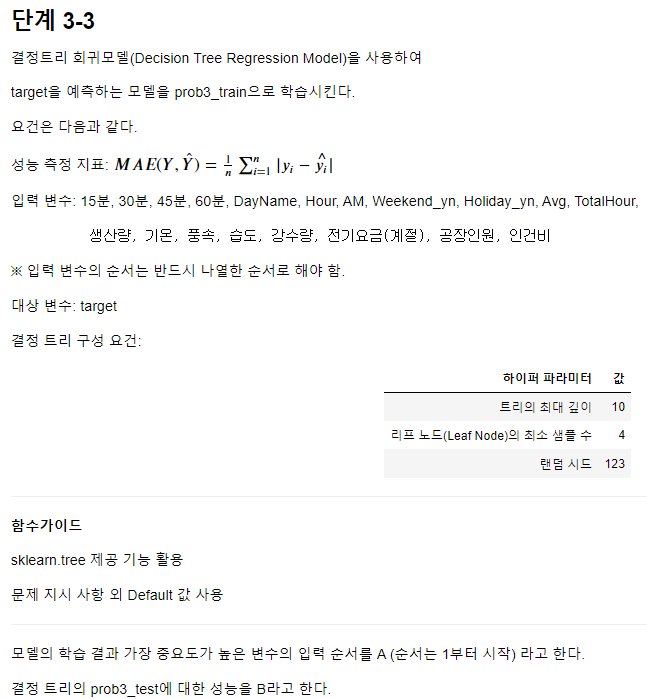

```python
Image('8.png')
```

```python
from sklearn.metrics import mean_absolute_error # 성능 측정 지표:  𝑀𝐴𝐸
from sklearn.tree import DecisionTreeRegressor, DecisionTreeClassifier

# 입력변수를 DataFrame에서의 입력 변수와 동일하게 제시 되었는데요,
# 문자열 연산을 통해 입력 변수 리스트를 간단히 만들어 봅니다.
X_dt = '15분, 30분, 45분, 60분, DayName, Hour, AM, Weekend_yn, Holiday_yn, Avg, \
        TotalHour, 생산량, 기온, 풍속, 습도, 강수량, 전기요금(계절), 공장인원, 인건비'
X_dt = [i.strip() for i in X_dt.split(',')]

print(X_dt)
print(type(X_dt))
```

```
['15분', '30분', '45분', '60분', 'DayName', 'Hour', 'AM', 'Weekend_yn', 'Holiday_yn', 'Avg', 'TotalHour', '생산량', '기온', '풍속', '습도', '강수량', '전기요금(계절)', '공장인원', '인건비']
<class 'list'>
```

```python
reg_dt = DecisionTreeRegressor(
    max_depth=10, # 트리의 최대 깊이: 10
    min_samples_leaf=4, # 리프 노드(Leaf Node)의 최소 샘플 수: 4
    random_state=123# 랜덤 시드:123
)

reg_dt.fit(df_prob3_train[X_dt], df_prob3_train['target'])
```

```
DecisionTreeRegressor(criterion='mse', max_depth=10, max_features=None,
                      max_leaf_nodes=None, min_impurity_decrease=0.0,
                      min_impurity_split=None, min_samples_leaf=4,
                      min_samples_split=2, min_weight_fraction_leaf=0.0,
                      presort=False, random_state=123, splitter='best')
```

```python
reg_dt.feature_importances_
```

```
array([0.00568971, 0.01820437, 0.02433534, 0.03155363, 0.31249107,
       0.13836694, 0.0025863 , 0.011507  , 0.00552584, 0.18448738,
       0.00698797, 0.00246119, 0.12222486, 0.00835318, 0.04782553,
       0.01473692, 0.05613957, 0.00594418, 0.00057904])
```

```python
'''
이 코드는 `DecisionTreeRegressor` 모델을 사용하여 피처의 중요도를 계산한 후,
가장 중요한 피처의 인덱스와 이름을 찾는 과정을 보여줍니다.

1. 피처 리스트 생성:
    - `X_dt` 문자열은 모델에 사용할 피처(특징)들의 이름을 나열합니다.
    - `split(',')`를 사용하여 문자열을 쉼표(,) 기준으로 분리하여 리스트로 만듭니다.
    - `strip()`을 사용하여 각 피처 이름에서 앞뒤 공백을 제거합니다.
    - 최종적으로 `X_dt`는 피처 이름들의 리스트가 됩니다.

2. 결정 트리 회귀 모델 생성 및 학습:
    - `DecisionTreeRegressor` 모델을 생성합니다.
        - `max_depth=10`: 트리의 최대 깊이를 10으로 설정합니다.
        - `min_samples_leaf=4`: 리프 노드의 최소 샘플 수를 4로 설정합니다.
    - `reg_dt.fit(df_prob3_train[X_dt], df_prob3_train['target'])`는 `df_prob3_train` 데이터프레임을 사용하여 모델을 학습시킵니다.
        - `df_prob3_train[X_dt]`는 피처 데이터입니다.
        - `df_prob3_train['target']`는 타깃 변수입니다.

3. 가장 중요한 피처의 인덱스와 이름 찾기:
    - `reg_dt.feature_importances_`는 각 피처의 중요도를 나타내는 배열을 반환합니다.
    - `np.argmax(reg_dt.feature_importances_)`는 피처 중요도 배열에서 가장 큰 값의 인덱스를 반환합니다.
    - `+ 1`은 인덱스를 1부터 시작하는 형식으로 변환합니다. (파이썬에서는 기본적으로 0부터 시작)
    - `A`는 가장 중요한 피처의 인덱스를 의미합니다.
    - `X_dt[np.argmax(reg_dt.feature_importances_)]`는 가장 중요한 피처의 이름을 반환합니다.
'''

A = np.argmax(reg_dt.feature_importances_) + 1
A, X_dt[np.argmax(reg_dt.feature_importances_)]
```

```
(5, 'DayName')
```

```python
# 요건에는 없지만 참고삼아, train에 대한 성능을 측정해봅니다.
B = mean_absolute_error(df_prob3_test['target'], reg_dt.predict(df_prob3_test[X_dt]))
(
    B,
    mean_absolute_error(df_prob3_train['target'], reg_dt.predict(df_prob3_train[X_dt]))
)
```

```
(37.27394388956255, 46.75807226356938)
```

```python
# 위 설명과 약간 중복되지만 추가 설명
'''
위 코드는 `DecisionTreeRegressor`를 사용하여 회귀 모델을 학습시키고, 모델의 성능 및 피처 중요도를 평가하는 과정을 포함하고 있습니다.

### 1. 데이터 전처리:
- `X_dt` 문자열 정의: 모델에 사용할 독립 변수들의 이름을 나열합니다.
- 리스트로 변환: 쉼표로 구분된 문자열을 리스트로 변환하고, 각 항목의 앞뒤 공백을 제거합니다.

### 2. 결정 트리 회귀 모델 학습:
reg_dt = DecisionTreeRegressor(
    max_depth=10, # 트리의 최대 깊이: 10
    min_samples_leaf=4, # 리프 노드의 최소 샘플 수: 4
    random_state=123 # 랜덤 시드: 123
)
reg_dt.fit(df_prob3_train[X_dt], df_prob3_train['target'])

- 모델 초기화:
  - `max_depth=10`: 결정 트리의 최대 깊이를 10으로 제한합니다. 이는 트리가 과적합(overfitting)되는 것을 방지합니다.
  - `min_samples_leaf=4`: 각 리프 노드에 최소한 4개의 샘플이 있어야 합니다.
      이는 모델이 지나치게 세부적으로 학습하지 않도록 합니다.
- 모델 학습: `df_prob3_train` 데이터프레임의 `X_dt` 열을 독립 변수로, `target` 열을 종속 변수로 사용하여 모델을 학습시킵니다.

### 3. 가장 중요한 피처 찾기:
- 피처 중요도 계산: `reg_dt.feature_importances_`는 각 피처의 중요도를 나타내는 배열을 반환합니다.
- 가장 중요한 피처 찾기: `np.argmax(reg_dt.feature_importances_)`는 가장 중요한 피처의 인덱스를 반환합니다.
    여기에 `+1`을 더해 `A`에 저장합니다(인덱스가 0부터 시작하므로 1을 더함).
- 피처 이름과 중요도 출력: 가장 중요한 피처의 인덱스와 그 이름을 출력합니다.

### 4. 모델 성능 평가:
- 테스트 데이터에 대한 성능:
  - `mean_absolute_error(df_prob3_test['target'], reg_dt.predict(df_prob3_test[X_dt]))`는
      테스트 데이터에서 예측값과 실제값 간의 평균 절대 오차(MAE)를 계산하여 `B`에 저장합니다.
- 학습 데이터에 대한 성능:
  - `mean_absolute_error(df_prob3_train['target'], reg_dt.predict(df_prob3_train[X_dt]))`는
      학습 데이터에서의 평균 절대 오차를 계산합니다.
- 출력: 두 개의 MAE 값을 튜플로 반환하여 출력합니다. 첫 번째 값은 테스트 데이터에서의 MAE(`B`), 두 번째 값은 학습 데이터에서의 MAE입니다.

### 전체적인 동작 요약:
1. `X_dt` 리스트를 생성하여 모델에 사용할 피처들을 정의합니다.
2. `DecisionTreeRegressor` 모델을 설정하고 학습시킵니다.
3. 모델에서 가장 중요한 피처를 식별하고 출력합니다.
4. 모델의 성능을 평가하기 위해 테스트 데이터와 학습 데이터에서의 평균 절대 오차(MAE)를 계산하여 출력합니다.

이 과정을 통해 모델이 주어진 데이터에서 어떤 피처가 가장 중요한지를 알 수 있고,
모델의 예측 성능을 학습 데이터와 테스트 데이터에서 평가할 수 있습니다.
'''

print('')
```

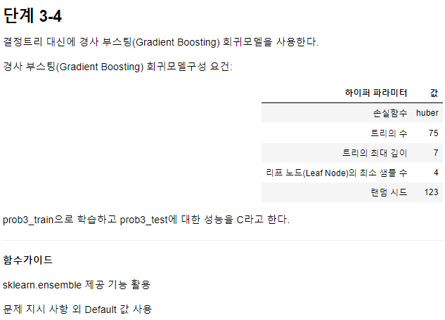

```python
Image('1-3.png')
```

```python
'''
코드는 `GradientBoostingRegressor`를 사용하여 회귀 모델을 학습시키고, 모델의 성능을 평가하는 과정을 포함하고 있습니다.

### 1. 데이터 전처리:
- `X_gb` 문자열 정의: 모델에 사용할 독립 변수들의 이름을 나열합니다.
- 리스트로 변환: 쉼표로 구분된 문자열을 리스트로 변환하고, 각 항목의 앞뒤 공백을 제거합니다.

### 2. 그레디언트 부스팅 회귀 모델 학습:
- 모델 초기화:
  - `loss='huber'`: Huber 손실 함수를 사용합니다. Huber 손실 함수는 평균 제곱 오차(MSE)와 평균 절대 오차(MAE)의
      특성을 결합하여, 이상치(outlier)에 강건한 모델을 만듭니다.
  - `n_estimators=75`: 부스팅 과정에서 사용할 트리의 수를 75로 설정합니다.
      더 많은 트리는 모델의 성능을 향상시킬 수 있지만 과적합의 위험도 있습니다.
  - `max_depth=7`: 각 결정 트리의 최대 깊이를 7로 제한합니다. 이는 모델이 과적합되는 것을 방지합니다.
  - `min_samples_leaf=4`: 각 리프 노드에 최소한 4개의 샘플이 있어야 합니다. 이는 모델이 지나치게 세부적으로 학습하지 않도록 합니다.
  - `random_state=123`: 랜덤 시드를 설정하여 재현성을 보장합니다.
- 모델 학습: `df_prob3_train` 데이터프레임의 `X_gb` 열을 독립 변수로, `target` 열을 종속 변수로 사용하여 모델을 학습시킵니다.

### 3. 모델 성능 평가:
- 테스트 데이터에 대한 성능:
  - `mean_absolute_error(df_prob3_test['target'], reg_gb.predict(df_prob3_test[X_gb]))`는
      테스트 데이터에서 예측값과 실제값 간의 평균 절대 오차(MAE)를 계산하여 `C`에 저장합니다.
- 학습 데이터에 대한 성능:
  - `mean_absolute_error(df_prob3_train['target'], reg_gb.predict(df_prob3_train[X_gb]))`는 학습 데이터에서의 평균절대오차를 계산합니다.
- 출력: 두 개의 MAE 값을 튜플로 반환하여 출력합니다.
    첫 번째 값은 테스트 데이터에서의 MAE(`C`), 두 번째 값은 학습 데이터에서의 MAE입니다.

### 전체적인 동작 요약:
1. `X_gb` 리스트를 생성하여 모델에 사용할 피처들을 정의합니다.
2. `GradientBoostingRegressor` 모델을 설정하고 학습시킵니다.
3. 모델의 성능을 평가하기 위해 테스트 데이터와 학습 데이터에서의 평균 절대 오차(MAE)를 계산하여 출력합니다.

이 과정을 통해 모델이 주어진 데이터에서 얼마나 잘 예측하는지를 평가할 수 있으며,
테스트 데이터와 학습 데이터에서의 성능을 비교하여 모델의 과적합 여부를 확인할 수 있습니다.
'''

from sklearn.metrics import mean_absolute_error # 성능 측정 지표:  𝑀𝐴𝐸
from sklearn.ensemble import GradientBoostingRegressor

X_gb = '15분, 30분, 45분, 60분, DayName, Hour, AM, Weekend_yn, Holiday_yn, Avg, \
        TotalHour, 생산량, 기온, 풍속, 습도, 강수량, 전기요금(계절), 공장인원, 인건비'
X_gb = [i.strip() for i in X_gb.split(',')]

reg_gb = GradientBoostingRegressor(
    loss = 'huber', # 손실함수: huber
    n_estimators = 75, # 트리의 수: 75
    max_depth = 7,# 트리의 최대 깊이: 7
    min_samples_leaf = 4,# 리프 노드(Leaf Node)의 최소 샘플 수: 4
    random_state = 123# 랜덤 시드: 123
)

reg_gb.fit(df_prob3_train[X_gb], df_prob3_train['target'])

C = mean_absolute_error(df_prob3_test['target'], reg_gb.predict(df_prob3_test[X_gb]))
(
    C,
    mean_absolute_error(df_prob3_train['target'], reg_gb.predict(df_prob3_train[X_gb]))
)
```

```
(36.04762917818188, 35.842003600642194)
```

```python
A, B, C, A + B + C, round(A + B + C, 3)
```

```
(5, 37.27394388956255, 36.04762917818188, 78.32157306774442, 78.322)
```

A + B + C를 소수점 넷째 자리에서 반올림하여 셋째 자리까지 적으시오

**78.322**

## 문제 4

DateHour를 기준으로 동일한 시각의 n일 이전의 TotalHour를 파생 변수 lag_n이라고 한다.

예를 들어 DateHour가 2021-01-07 00:00:00이라면,

lag_1은 2021-01-06 00:00:00의 TotalHour값인 96이 된다.

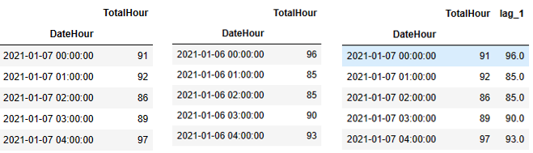

## 단계 4-1

prob3에 lag_1 ~ lag_6까지의 6개의 파생 변수를 추가하여 prob4를 만든다.

prob4에 lag_1 ~ lag_6까지 하나라도 결측치가 있다면 삭제한다.

```python
'''
코드는 `df_prob3` 데이터프레임에 대해 시계열 특성을 반영한 새로운 데이터프레임 `df_prob4`를 생성합니다.
구체적으로, `df_prob3`의 `TotalHour` 컬럼을 24시간 단위로 여러 번 시프트(이동)하여 새로운 컬럼으로 추가합니다.
이를 통해 각 시점에서의 이전 24시간, 48시간, ..., 144시간 전의 `TotalHour` 값을 포함하는 데이터프레임을 만듭니다.
그런 다음, 결측값이 있는 행을 제거합니다.

1. 리스트 컴프리헨션을 사용하여 시프트된 시리즈를 생성:
    - `range(1, 7)`은 1부터 6까지의 정수 시퀀스를 생성합니다.
    - `df_prob3['TotalHour'].shift(24 * i)`는 `TotalHour` 컬럼을 24시간, 48시간, ..., 144시간(6일)만큼 시프트합니다.
    - `.rename('lag_{}'.format(i))`는 각각의 시프트된 시리즈의 이름을 `lag_1`, `lag_2`, ..., `lag_6`으로 변경합니다.

2. pd.concat를 사용하여 원래 데이터프레임과 시프트된 시리즈들을 합치기:
    - `[df_prob3]`는 원래 데이터프레임을 리스트로 감쌉니다.
    - `[df_prob3] + [df_prob3['TotalHour'].shift(24 * i).rename('lag_{}'.format(i)) for i in range(1, 7)]`는
        원래 데이터프레임과 시프트된 시리즈들을 하나의 리스트로 결합합니다.
    - `pd.concat(..., axis=1)`는 이 리스트의 요소들을 열(axis=1) 기준으로 병합하여 새로운 데이터프레임을 생성합니다.

3. dropna를 사용하여 결측값이 있는 행 제거:
    .dropna()
    - 시프트된 시리즈는 앞쪽에 결측값(NaN)을 가질 수밖에 없으므로, 시프트된 시리즈를 추가한 후에는 결측값이 있는 행이 생깁니다.
    - `.dropna()`는 이러한 결측값이 있는 행을 제거합니다.

### 결과
결과 데이터프레임 `df_prob4`는 원래 `df_prob3`에 `lag_1`, `lag_2`, ..., `lag_6` 열이 추가된 형태가 되며,
각 열에는 해당 시간만큼 시프트된 `TotalHour` 값이 들어갑니다.
결측값이 포함된 행들은 `dropna()`에 의해 제거되어, 모든 열에 값이 있는 행만 남게 됩니다.

이렇게 하면 시계열 데이터의 시점별 과거 값을 분석하거나 예측 모델에 사용할 수 있는 특성을 쉽게 추가할 수 있습니다.
'''

# 방법 1: shift를 이용하여 구해봅니다.
# 먼저 lag 변수들을 list comprehension을 이용해 만들고 이를 df_prob3와 함께 결합하여 df_prob4를 만듭니다.
# lag을 제외한 나머지 변수에 결측이 없습니다. dropna를 통해 일괄적으로 제거해도됩니다.

df_prob4 = pd.concat(
                [df_prob3] + [df_prob3['TotalHour'].shift(24 * i).rename('lag_{}'.format(i)) for i in range(1, 7)]
                , axis=1).dropna()

display(df_prob4.head())
df_prob4.shape
```

| DateHour | 15분 | 30분 | 45분 | 60분 | DayName | Hour | AM | Weekend_yn | Holiday_yn | Avg | ... | 전기요금(계절) | 공장인원 | 인건비 | target | lag_1 | lag_2 | lag_3 | lag_4 | lag_5 | lag_6 |
| --- | --- | --- | --- | --- | --- | --- | --- | --- | --- | --- | --- | --- | --- | --- | --- | --- | --- | --- | --- | --- | --- |
| 2021-01-07 00:00:00 | 22 | 22 | 22 | 25 | 3 | 0 | 0 | 0 | 0 | 22.75 | ... | 109.8 | 0.000000 | 1.5 | 252.0 | 96.0 | 96.0 | 271.0 | 88.0 | 253.0 | 245.0 |
| 2021-01-07 01:00:00 | 26 | 22 | 22 | 22 | 3 | 1 | 0 | 0 | 0 | 23.00 | ... | 109.8 | 0.369565 | 1.5 | 396.0 | 85.0 | 85.0 | 432.0 | 99.0 | 418.0 | 418.0 |
| 2021-01-07 02:00:00 | 22 | 21 | 21 | 22 | 3 | 2 | 0 | 0 | 0 | 21.50 | ... | 109.8 | 0.000000 | 1.5 | 411.0 | 85.0 | 85.0 | 439.0 | 88.0 | 415.0 | 415.0 |
| 2021-01-07 03:00:00 | 22 | 22 | 22 | 23 | 3 | 3 | 0 | 0 | 0 | 22.25 | ... | 109.8 | 0.629213 | 1.5 | 398.0 | 90.0 | 90.0 | 426.0 | 88.0 | 421.0 | 421.0 |
| 2021-01-07 04:00:00 | 22 | 26 | 26 | 23 | 3 | 4 | 0 | 0 | 0 | 24.25 | ... | 109.8 | 2.865979 | 1.5 | 420.0 | 93.0 | 93.0 | 435.0 | 95.0 | 427.0 | 427.0 |

5 rows × 26 columns

```
(6000, 26)
```

```python
'''
이 코드는 `df_prob3` 데이터프레임에 대해 시계열 특성을 반영한 새로운 데이터프레임 `df_prob4`를 생성합니다.
각 `TotalHour` 값을 1일부터 6일까지의 기간만큼 시프트하여 새로운 열로 추가합니다.
`pd.concat`을 사용하여 이 시프트된 열들을 원래 데이터프레임과 병합합니다.
중요한 점은 `join='inner'` 옵션을 사용하여 공통 인덱스에 대해서만 병합하는 것입니다.

코드의 각 부분을 상세히 설명하면 다음과 같습니다:

1. 리스트 컴프리헨션을 사용하여 시프트된 시리즈를 생성:
    - `range(1, 7)`은 1부터 6까지의 정수 시퀀스를 생성합니다.
    - `df_prob3['TotalHour'].values`는 `TotalHour` 열의 값을 배열로 반환합니다.
    - `df_prob3['TotalHour'].index + pd.Timedelta(days=i)`는 인덱스를 i일 만큼 시프트합니다.
    - `pd.Series(..., name='lag_{}'.format(i))`는 시프트된 값을 가지는
        새로운 시리즈를 생성하고, 이름을 `lag_i`로 지정합니다.

2. pd.concat을 사용하여 원래 데이터프레임과 시프트된 시리즈들을 합치기:
    - `[df_prob3]`는 원래 데이터프레임을 리스트로 감쌉니다.
    - `[df_prob3] + ...`는 원래 데이터프레임과 시프트된 시리즈들을 하나의 리스트로 결합합니다.
    - `pd.concat(..., axis=1, join='inner')`는 이 리스트의 요소들을 열(axis=1) 기준으로 병합하여 새로운 데이터프레임을 생성합니다.
        `join='inner'`는 공통 인덱스만 남겨 병합합니다.

3. dropna는 사용되지 않았지만 `join='inner'`가 같은 역할을 함:
    - `join='inner'` 옵션은 공통 인덱스를 기준으로 병합하여 결측값이 포함된 행을 자동으로 제거합니다.

### 결과
결과 데이터프레임 `df_prob4`는 원래 `df_prob3`에 `lag_1`, `lag_2`, ..., `lag_6` 열이 추가된 형태가 되며,
각 열에는 해당 기간만큼 시프트된 `TotalHour` 값이 들어갑니다.
공통 인덱스만 남기고 병합하므로, 인덱스가 일치하지 않는 행들은 자동으로 제거됩니다.

이렇게 하면 시계열 데이터의 시점별 과거 값을 분석하거나 예측 모델에 사용할 수 있는 특성을 쉽게 추가할 수 있습니다.
'''

# 방법 2: index를 변경하여 변수를 만듭니다.
# 먼저 lag 변수들을 list comprehension을 이용해 만들고 이를 df_prob3와 함께 결합하여 df_prob4를 만듭니다.
# join 설정을 inner로 하면 결합하는 모든 요소들에 공통으로 등장하는 인덱스에 해당하는 행들만을 남깁니다.

df_prob4 = pd.concat(
    [df_prob3] + [
        pd.Series(df_prob3['TotalHour'].values, index=df_prob3['TotalHour'].index
                  + pd.Timedelta(days=i), name='lag_{}'.format(i)) for i in range(1, 7)
    ],
    axis=1, join='inner'
)

display(df_prob4.head())
df_prob4.shape
```

| DateHour | 15분 | 30분 | 45분 | 60분 | DayName | Hour | AM | Weekend_yn | Holiday_yn | Avg | ... | 전기요금(계절) | 공장인원 | 인건비 | target | lag_1 | lag_2 | lag_3 | lag_4 | lag_5 | lag_6 |
| --- | --- | --- | --- | --- | --- | --- | --- | --- | --- | --- | --- | --- | --- | --- | --- | --- | --- | --- | --- | --- | --- |
| 2021-01-07 00:00:00 | 22 | 22 | 22 | 25 | 3 | 0 | 0 | 0 | 0 | 22.75 | ... | 109.8 | 0.000000 | 1.5 | 252.0 | 96 | 96 | 271 | 88 | 253 | 245 |
| 2021-01-07 01:00:00 | 26 | 22 | 22 | 22 | 3 | 1 | 0 | 0 | 0 | 23.00 | ... | 109.8 | 0.369565 | 1.5 | 396.0 | 85 | 85 | 432 | 99 | 418 | 418 |
| 2021-01-07 02:00:00 | 22 | 21 | 21 | 22 | 3 | 2 | 0 | 0 | 0 | 21.50 | ... | 109.8 | 0.000000 | 1.5 | 411.0 | 85 | 85 | 439 | 88 | 415 | 415 |
| 2021-01-07 03:00:00 | 22 | 22 | 22 | 23 | 3 | 3 | 0 | 0 | 0 | 22.25 | ... | 109.8 | 0.629213 | 1.5 | 398.0 | 90 | 90 | 426 | 88 | 421 | 421 |
| 2021-01-07 04:00:00 | 22 | 26 | 26 | 23 | 3 | 4 | 0 | 0 | 0 | 24.25 | ... | 109.8 | 2.865979 | 1.5 | 420.0 | 93 | 93 | 435 | 95 | 427 | 427 |

5 rows × 26 columns

```
(6000, 26)
```

```python
# 위 두가지 방식의 비교

'''
두 코드 모두 `df_prob3` 데이터프레임을 기준으로 특정 시점만큼 시프트된 `TotalHour` 값을 새로운 열로 추가하여
`df_prob4`를 생성합니다. 그러나 두 접근 방식에는 중요한 차이점이 있습니다. 각각의 동작을 비교하여 자세히 설명하겠습니다.

### 첫 번째 코드
#### 동작 설명:

1. 리스트 컴프리헨션:
   - `shift(24 * i)`는 `TotalHour` 열을 `24 * i`만큼 시프트합니다. 즉, 24시간씩 (1일씩) 시프트된 값을 생성합니다.
   - `rename('lag_{}'.format(i))`는 시프트된 시리즈의 이름을 `lag_i`로 변경합니다.
2. pd.concat:
   - `[df_prob3] + ...`는 원래 데이터프레임과 시프트된 시리즈들을 하나의 리스트로 결합합니다.
   - `pd.concat(..., axis=1)`는 이 리스트의 요소들을 열(axis=1) 기준으로 병합하여 새로운 데이터프레임을 생성합니다.
3. dropna:
   - 병합된 데이터프레임에서 결측값이 포함된 행을 제거합니다.

#### 결과:
- 각 시프트된 시리즈는 원래 데이터프레임의 인덱스와 맞지 않는 부분이 NaN으로 채워집니다.
- `dropna()`를 사용하여 이 NaN 행들을 제거합니다.
- 결과적으로, 시프트된 시리즈와 공통 인덱스를 가진 행들만 남게 됩니다.

### 두 번째 코드
#### 동작 설명:

1. 리스트 컴프리헨션:
   - `df_prob3['TotalHour'].values`는 `TotalHour` 열의 값을 배열로 반환합니다.
   - `df_prob3['TotalHour'].index + pd.Timedelta(days=i)`는 인덱스를 `i`일 만큼 시프트합니다.
   - `pd.Series(..., name='lag_{}'.format(i))`는 시프트된 값을 가지는 새로운 시리즈를 생성하고, 이름을 `lag_i`로 지정합니다.
2. pd.concat:
   - `[df_prob3] + ...`는 원래 데이터프레임과 시프트된 시리즈들을 하나의 리스트로 결합합니다.
   - `pd.concat(..., axis=1, join='inner')`는 공통 인덱스를 기준으로 열(axis=1) 기준으로 병합하여 새로운 데이터프레임을 생성합니다.

#### 결과:
- 시프트된 시리즈들은 원래 데이터프레임의 인덱스와 `i`일 만큼 시프트된 인덱스를 가지게 됩니다.
- `join='inner'` 옵션을 사용하여 병합된 데이터프레임에서 공통 인덱스를 가진 행들만 남깁니다.
- 이로 인해 NaN 값이 생성되지 않고, 인덱스가 일치하는 행들만 포함됩니다.

### 비교 및 차이점:
1. 시프트 방식:
   - 첫 번째 코드는 `shift(24 * i)`를 사용하여 24시간 단위로 시프트합니다.
   - 두 번째 코드는 `pd.Timedelta(days=i)`를 사용하여 일 단위로 시프트합니다.
2. 결측값 처리:
   - 첫 번째 코드는 `dropna()`를 사용하여 병합 후 결측값이 포함된 행을 제거합니다.
   - 두 번째 코드는 `join='inner'`를 사용하여 병합 시 공통 인덱스만 남기므로 결측값이 포함되지 않습니다.
3. 결과 데이터프레임:
   - 첫 번째 코드의 결과는 결측값이 제거된 데이터프레임입니다.
   - 두 번째 코드의 결과는 공통 인덱스만 남긴 데이터프레임입니다.
'''

print('')
```

**Tip!**

target의 시점을 기준으로 이전 7일의 TotalHour, Avg의 평균을 구하고,

이를 TotalHour_mean7, Avg_mean7으로 만들어 봅니다.

결측이 하나라도 있으면 뺍니다.

```python
'''
이 코드는 `df_prob3` 데이터프레임의 `TotalHour`와 `Avg` 열에 대해 각각의 시계열을 7일 간의 이동 평균으로 변환합니다.

1. 리스트 컴프리헨션:
   - `for i in range(0, 7)`는 0에서 6까지의 범위 내에서 반복합니다.
   - `df_prob3[j]`는 `df_prob3` 데이터프레임의 열(`TotalHour` 또는 `Avg`)을 선택합니다.
   - `shift(24 * i)`는 선택한 열을 `24 * i`만큼 시프트합니다. 즉, 시간 단위로 시프트하므로 `24 * i`는 i일을 의미합니다.
2. 첫 번째 pd.concat:
   - 시프트된 7개의 시리즈를 열 방향으로 병합합니다.
   - 결과는 7개의 열을 가진 데이터프레임이 됩니다.
3. dropna:
   - 병합된 데이터프레임에서 NaN 값을 포함한 행들을 제거합니다.
   - 시프트 연산으로 인해 일부 값이 NaN이 되므로, 이 행들을 제거하여 완전한 데이터만 남깁니다.
4. mean:
   - 각 행에 대해 7개의 열의 평균을 계산합니다.
   - `axis=1`은 행 방향으로 평균을 계산한다는 의미입니다.
   - 결과는 각 행에 대한 7일 이동 평균을 나타내는 시리즈입니다.
5. rename:
   - 계산된 평균 시리즈의 이름을 `TotalHour_mean7` 또는 `Avg_mean7`로 변경합니다.
6. 외부 리스트 컴프리헨션:
   - 위의 과정을 `TotalHour`와 `Avg` 열 각각에 대해 반복합니다.
   - 두 개의 시리즈 리스트를 생성합니다.
7. 두 번째 pd.concat:
   - 두 개의 시리즈(`TotalHour_mean7` 및 `Avg_mean7`)를 열 방향으로 병합합니다.
   - 결과는 두 개의 열(`TotalHour_mean7` 및 `Avg_mean7`)을 가진 데이터프레임이 됩니다.

### 종합적으로 설명:
1. `df_prob3` 데이터프레임의 `TotalHour` 및 `Avg` 열 각각에 대해 0일, 1일, ..., 6일 시프트된 버전을 생성합니다.
2. 시프트된 버전들을 열 방향으로 병합한 후, NaN 값을 제거합니다.
3. 각 행에 대해 7일 이동 평균을 계산하고, 결과 시리즈를 적절한 이름으로 변경합니다.
4. `TotalHour`와 `Avg`에 대한 각각의 결과 시리즈를 다시 열 방향으로 병합하여 최종 데이터프레임을 생성합니다.

이 최종 데이터프레임은 `TotalHour_mean7` 및 `Avg_mean7` 열을 포함하며, 이는 각각의 7일 이동 평균 값을 나타냅니다.
'''

# target을 기준으로 이전 7일의 동일 시간에 대한 TotalHour의 평균과 Avg의 평균을 구해봅니다.
# target은 TotalHour를 기준으로 하루 앞선 시점의 동일 시간의 TotalHour이므로 0일도 포함 시킵니다.

pd.concat(
    [
        pd.concat(
            [df_prob3[j].shift(24 * i) for i in range(0, 7)], axis=1
        ).dropna().mean(axis=1).rename('{}_mean7'.format(j)) for j in ['TotalHour', 'Avg']
    ], axis=1
)
```

| DateHour | TotalHour_mean7 | Avg_mean7 |
| --- | --- | --- |
| 2021-01-07 00:00:00 | 162.857143 | 40.714286 |
| 2021-01-07 01:00:00 | 232.714286 | 58.178571 |
| 2021-01-07 02:00:00 | 230.428571 | 57.607143 |
| 2021-01-07 03:00:00 | 232.142857 | 58.035714 |
| 2021-01-07 04:00:00 | 238.142857 | 59.535714 |
| ... | ... | ... |
| 2021-09-13 19:00:00 | 447.285714 | 111.821429 |
| 2021-09-13 20:00:00 | 370.571429 | 92.642857 |
| 2021-09-13 21:00:00 | 381.428571 | 95.357143 |
| 2021-09-13 22:00:00 | 336.285714 | 84.071429 |
| 2021-09-13 23:00:00 | 320.857143 | 80.214286 |

6000 rows × 2 columns

```python
'''
이 코드는 `df_prob3` 데이터프레임의 `TotalHour`와 `Avg` 열에 대해
각각의 시계열 데이터를 7일 간의 이동 평균으로 변환하는 작업을 수행합니다.

### 1. 리스트 컴프리헨션
이 부분은 `TotalHour`와 `Avg` 두 개의 열에 대해 동일한 처리를 반복합니다.
즉, 리스트 컴프리헨션은 각 열에 대해 다음 작업을 수행합니다:

#### a. `shift`와 `rename`
- `for i in range(0, 7)`: 0에서 6까지 반복합니다.
- `df_prob3[j]`: `df_prob3` 데이터프레임의 열(`TotalHour` 또는 `Avg`)을 선택합니다.
- `shift(i * 24)`: 선택된 열을 `i * 24`만큼 시프트합니다.
    이는 하루 단위(24시간)를 기준으로 시프트하므로, i일만큼 시프트하게 됩니다.
- `rename('lag_{}'.format(i))`: 시프트된 열의 이름을 `lag_i`로 변경합니다.

이 리스트 컴프리헨션은 시프트된 7개의 시리즈를 생성합니다.

#### b. `pd.concat`
- 시프트된 7개의 시리즈를 열 방향으로 병합합니다.
- 결과는 7개의 열을 가진 데이터프레임이 됩니다.

#### c. `dropna`
- 병합된 데이터프레임에서 NaN 값을 포함한 행들을 제거합니다.
    시프트 연산으로 인해 일부 값이 NaN이 되므로, 이 행들을 제거하여 완전한 데이터만 남깁니다.

#### d. `mean`
- 각 행에 대해 7개의 열의 평균을 계산합니다.
- `axis=1`은 행 방향으로 평균을 계산한다는 의미입니다.
- 결과는 각 행에 대한 7일 이동 평균을 나타내는 시리즈입니다.

#### e. `rename`
- 계산된 평균 시리즈의 이름을 `TotalHour_mean7` 또는 `Avg_mean7`로 변경합니다.

### 2. 외부 `pd.concat`
- 위의 리스트 컴프리헨션에서 생성된 두 개의 시리즈(`TotalHour_mean7` 및 `Avg_mean7`)를 열 방향으로 병합합니다.
- 결과는 두 개의 열(`TotalHour_mean7` 및 `Avg_mean7`)을 가진 데이터프레임이 됩니다.

### 종합적으로 설명
1. `df_prob3` 데이터프레임의 `TotalHour`와 `Avg` 열 각각에 대해 0일, 1일, ..., 6일 시프트된 버전을 생성합니다.
2. 시프트된 버전들을 열 방향으로 병합한 후, NaN 값을 제거합니다.
3. 각 행에 대해 7개의 열의 평균을 계산하고, 결과 시리즈를 적절한 이름으로 변경합니다.
4. `TotalHour`와 `Avg`에 대한 각각의 결과 시리즈를 다시 열 방향으로 병합하여 최종 데이터프레임을 생성합니다.

이 최종 데이터프레임은 `TotalHour_mean7` 및 `Avg_mean7` 열을 포함하며, 이는 각각의 7일 이동 평균 값을 나타냅니다.
'''

# index 기반의 방법으로 만들어봅니다.

pd.concat(
    [
        pd.concat(
            [df_prob3[j].shift(i * 24).rename('lag_{}'.format(i)) for i in range(0, 7)], axis=1
        ).dropna().mean(axis=1).rename('{}_mean7'.format(j)) for j in ['TotalHour', 'Avg']
    ], axis=1
)
```

| DateHour | TotalHour_mean7 | Avg_mean7 |
| --- | --- | --- |
| 2021-01-07 00:00:00 | 162.857143 | 40.714286 |
| 2021-01-07 01:00:00 | 232.714286 | 58.178571 |
| 2021-01-07 02:00:00 | 230.428571 | 57.607143 |
| 2021-01-07 03:00:00 | 232.142857 | 58.035714 |
| 2021-01-07 04:00:00 | 238.142857 | 59.535714 |
| ... | ... | ... |
| 2021-09-13 19:00:00 | 447.285714 | 111.821429 |
| 2021-09-13 20:00:00 | 370.571429 | 92.642857 |
| 2021-09-13 21:00:00 | 381.428571 | 95.357143 |
| 2021-09-13 22:00:00 | 336.285714 | 84.071429 |
| 2021-09-13 23:00:00 | 320.857143 | 80.214286 |

6000 rows × 2 columns

```python
# 위 두가지 방식의 비교

'''
두 코드 모두 pandas 라이브러리를 사용하여 데이터 프레임 `df_prob3`의
특정 열들에 대해 7일 간격으로 이동 평균을 계산하는 기능을 수행합니다.
두 코드는 매우 유사하지만, 약간의 차이가 있습니다.

### 코드 1 설명:
1. List comprehension:
   - `for j in ['TotalHour', 'Avg']` : `df_prob3` 데이터 프레임의 두 열 'TotalHour'와 'Avg'에 대해 반복합니다.
2. Nested list comprehension:
   - `[df_prob3[j].shift(24 * i) for i in range(0, 7)]`:
       각 열 `j`에 대해 0부터 6까지 7일 간격(24시간 * i)으로 데이터를 이동시킵니다.
       예를 들어, `i=0`이면 원본 데이터를, `i=1`이면 하루 뒤로 이동한 데이터를 의미합니다.
3. Inner `pd.concat`:
   - `pd.concat(..., axis=1)`: 이 이동된 7개의 열들을 옆으로 붙여 새로운 데이터 프레임을 만듭니다.
4. Drop NA and Mean Calculation:
   - `.dropna().mean(axis=1)`: NaN 값을 가진 행을 제거하고, 각 행에 대해 7개의 이동된 열들의 평균을 계산합니다.
5. Rename:
   - `.rename('{}_mean7'.format(j))`: 계산된 평균 시리즈를 'TotalHour_mean7' 또는 'Avg_mean7'로 이름을 붙입니다.
6. Outer `pd.concat`:
   - `pd.concat(..., axis=1)`: 'TotalHour_mean7'과 'Avg_mean7' 두 시리즈를 옆으로 붙여 최종 데이터 프레임을 만듭니다.

### 코드 2 설명:
1. List comprehension:
   - `for j in ['TotalHour', 'Avg']`: 첫 번째 코드와 동일하게 'TotalHour'와 'Avg' 열에 대해 반복합니다.
2. Nested list comprehension:
   - `[df_prob3[j].shift(i * 24).rename('lag_{}'.format(i)) for i in range(0, 7)]`:
       각 열 `j`에 대해 0부터 6까지 7일 간격으로 데이터를 이동시키고, 각 이동된 시리즈에 'lag_0', 'lag_1', ..., 'lag_6'라는 이름을 붙입니다.
3. Inner `pd.concat`:
   - `pd.concat(..., axis=1)`: 이 이동된 7개의 열들을 옆으로 붙여 새로운 데이터 프레임을 만듭니다.
4. Drop NA and Mean Calculation:
   - `.dropna().mean(axis=1)`: NaN 값을 가진 행을 제거하고, 각 행에 대해 7개의 이동된 열들의 평균을 계산합니다.
5. Rename:
   - `.rename('{}_mean7'.format(j))`: 계산된 평균 시리즈를 'TotalHour_mean7' 또는 'Avg_mean7'로 이름을 붙입니다.
6. Outer `pd.concat`:
   - `pd.concat(..., axis=1)`: 'TotalHour_mean7'과 'Avg_mean7' 두 시리즈를 옆으로 붙여 최종 데이터 프레임을 만듭니다.

### 차이점 비교:
1. 열 이름 붙이기:
   - 첫 번째 코드에서는 이동된 열들에 별도의 이름을 붙이지 않습니다.
   - 두 번째 코드에서는 각 이동된 시리즈에 'lag_0', 'lag_1', ..., 'lag_6'라는 이름을 붙입니다.
       이는 디버깅이나 데이터 탐색 시 유용할 수 있습니다.
2. 기능적 차이:
   - 두 코드 모두 같은 결과(각 열에 대해 7일 이동 평균)를 산출합니다.
       하지만 두 번째 코드는 중간 결과물인 이동된 열들을 이름으로 명시함으로써 코드의 가독성을 약간 향상시킵니다.

### 결론:
두 코드 모두 비슷한 작업을 수행하며, 기능적으로 동일한 결과를 제공합니다.
그러나 두 번째 코드가 각 이동된 시리즈에 이름을 부여하여 가독성과 유지보수성을 조금 더 높이는 방식입니다.
이를 통해 코드 실행 시 중간 결과를 쉽게 확인할 수 있습니다.
'''

print('')
```

## 단계 4-2

학습용과 테스트용 데이터셋을 2021년 8월 14일 전과 이후로 분리

. prob4_train: DateHour 변수 기준으로 2021년 8월 14일 전(8월 14일 미포함) 데이터 (행의 수: 5256개)

. prob4_test: DateHour 변수 기준으로 2021년 8월 14일 이후(8월 14일 포함) 데이터 (행의 수: 744 개)

```python
'''
코드는 `df_prob4` 데이터프레임을 특정 날짜를 기준으로 훈련 데이터와 테스트 데이터로 분할하는 작업을 수행합니다.

### 동작 설명
1. 기준 날짜 설정:
   pd.to_datetime('2021-08-14')
   - 문자열 `'2021-08-14'`을 `pandas`의 `to_datetime` 함수를 사용하여 `Timestamp` 객체로 변환합니다.
   - 이는 특정 날짜를 기준으로 데이터를 분할할 때 사용됩니다.

2. 훈련 데이터셋 분할:
   df_prob4_train = df_prob4.loc[df_prob4.index < pd.to_datetime('2021-08-14')].copy()
   - `df_prob4.index < pd.to_datetime('2021-08-14')`는 `df_prob4` 데이터프레임의 인덱스가 `2021-08-14` 이전인 행들을 선택합니다.
   - `df_prob4.loc[...]`를 사용하여 선택된 행들로 구성된 새로운 데이터프레임을 생성합니다.
   - `.copy()` 메소드를 호출하여 원본 데이터프레임으로부터 독립적인 복사본을 만듭니다.
   - 결과적으로, `df_prob4_train`은 `2021-08-14` 이전의 데이터를 포함하는 훈련 데이터셋이 됩니다.

3. 테스트 데이터셋 분할:
   df_prob4_test = df_prob4.loc[df_prob4.index >= pd.to_datetime('2021-08-14')].copy()
   - `df_prob4.index >= pd.to_datetime('2021-08-14')`는
       `df_prob4` 데이터프레임의 인덱스가 `2021-08-14` 이후인 행들을 선택합니다.
   - `df_prob4.loc[...]`를 사용하여 선택된 행들로 구성된 새로운 데이터프레임을 생성합니다.
   - `.copy()` 메소드를 호출하여 원본 데이터프레임으로부터 독립적인 복사본을 만듭니다.
   - 결과적으로, `df_prob4_test`는 `2021-08-14` 이후의 데이터를 포함하는 테스트 데이터셋이 됩니다.

### 요약
- 이 코드의 목적은 `df_prob4` 데이터프레임을 날짜 `2021-08-14`을 기준으로 훈련 데이터셋(`df_prob4_train`)과
    테스트 데이터셋(`df_prob4_test`)으로 나누는 것입니다.
- `df_prob4_train`은 `2021-08-14` 이전의 데이터를 포함하고, `df_prob4_test`는 `2021-08-14` 이후의 데이터를 포함합니다.
- `.copy()` 메소드를 사용하여 각 분할된 데이터셋이 원본 데이터프레임 `df_prob4`로부터 독립적으로 존재하도록 합니다.
'''

df_prob4_train = df_prob4.loc[df_prob4.index < pd.to_datetime('2021-08-14')].copy()
df_prob4_test = df_prob4.loc[df_prob4.index >= pd.to_datetime('2021-08-14')].copy()
df_prob4_train.shape, df_prob4_test.shape
```

```
((5256, 26), (744, 26))
```

## 단계 4-3

prob4_train에서 TotalHour와 lag_1~6 를 표준화하고,

prob4_train의 표준화 설정으로 prob4_test의 TotalHour와 lag_1~6를 표준화한다.

**함수가이드**

sklearn.preprocessing 제공 기능 활용

문제 지시 사항 외 Default 값 사용

```python
'''
이 코드는 `StandardScaler`를 사용하여 훈련 데이터와 테스트 데이터의 특정 열을 표준화(정규화)하는 작업을 수행합니다.
표준화는 각 열의 값들이 평균이 0이고 표준편차가 1이 되도록 변환하는 과정입니다.

### 동작 설명

1. `StandardScaler` 객체 생성:
   - `StandardScaler`는 `scikit-learn` 라이브러리의 전처리 클래스입니다.
   - 각 열의 값들이 평균이 0이고 표준편차가 1이 되도록 변환합니다.
   - 이 객체를 생성함으로써 이후의 표준화 작업에 사용할 준비를 합니다.

2. 표준화할 열 목록 생성:
   - `X_std`는 표준화할 열 이름들의 리스트입니다.
   - `'TotalHour'` 열과 `'lag_1'`부터 `'lag_6'`까지의 열들이 포함됩니다.
   - `['lag_{}'.format(i) for i in range(1, 7)]`는 `lag_1`, `lag_2`, ..., `lag_6` 열 이름들을 동적으로 생성합니다.

3. 훈련 데이터에 대해 `StandardScaler`를 학습(fit):
   - `fit` 메소드를 사용하여 `df_prob4_train` 데이터프레임의 `X_std` 열들에 대해 `StandardScaler`를 학습시킵니다.
   - 여기서 학습이란 각 열의 평균과 표준편차를 계산하는 것을 의미합니다.
   - 이 평균과 표준편차는 이후의 변환(transform) 작업에 사용됩니다.

4. 훈련 데이터의 열들을 표준화:
   - `transform` 메소드를 사용하여 `df_prob4_train` 데이터프레임의 `X_std` 열들을 표준화합니다.
   - 각 열의 값들이 평균이 0이고 표준편차가 1이 되도록 변환됩니다.
   - 변환된 값들을 원래의 데이터프레임에 다시 할당합니다.

5. 테스트 데이터의 열들을 표준화:
   - 훈련 데이터에 대해 학습된 `StandardScaler`를 사용하여 `df_prob4_test` 데이터프레임의 `X_std` 열들을 표준화합니다.
   - `fit` 메소드를 사용하지 않고 `transform` 메소드만 사용하는 이유는,
       테스트 데이터는 훈련 데이터의 평균과 표준편차를 기준으로 변환해야 일관성을 유지할 수 있기 때문입니다.
   - 변환된 값들을 원래의 데이터프레임에 다시 할당합니다.

### 요약

- `StandardScaler`를 사용하여 특정 열들을 표준화하는 과정입니다.
- 훈련 데이터(`df_prob4_train`)의 평균과 표준편차를 기준으로 `StandardScaler`를 학습시킵니다.
- 학습된 `StandardScaler`를 사용하여 훈련 데이터와 테스트 데이터(`df_prob4_test`)를 변환합니다.
- 이 작업을 통해 훈련 데이터와 테스트 데이터의 특정 열들이 평균이 0이고 표준편차가 1이 되도록 표준화됩니다.
'''

from sklearn.preprocessing import StandardScaler

std_scaler = StandardScaler()

X_std = ['TotalHour'] + ['lag_{}'.format(i) for i in range(1, 7)]
print('X_std = ', X_std)

std_scaler.fit(df_prob4_train[X_std])

df_prob4_train[X_std] = std_scaler.transform(df_prob4_train[X_std])

df_prob4_test[X_std] = std_scaler.transform(df_prob4_test[X_std])
```

```
X_std =  ['TotalHour', 'lag_1', 'lag_2', 'lag_3', 'lag_4', 'lag_5', 'lag_6']
```

## 단계 4-4

SVR(Support Vector Regressor) 모델을 아래 요건에 3가지 커널(Kernel)로 prob4_train을 학습하고

prob4_test로 성능을 측정한다.

그 중 가장 좋은 성능을 보인 커널의 번호를 A(No.), 그 때의 성능을 B라고 한다.

성능 측정 지표: $MAE(Y, \hat{Y})=\frac{1}{n}\sum^n_{i=1}|y_i - \hat{y_i}|$

입력 변수: TotalHour, lag_1 ~ 6

대상 변수: target

커널함수:

1: $k(x_i,x_j)=\langle x_i,x_j \rangle$

2: $k(x_i,x_j)=(\gamma \langle x_i,x_j \rangle +1)^2,\gamma=0.1$

3: $k(x_i,x_j)=exp(-\gamma ||x_i-x_j||^2 ),\gamma=0.1$

$\langle x,x' \rangle:x,x'$ 의 내적,$||x_i-x_j||^2$:L2-norm

**함수가이드**

sklearn.svm.SVR, C=10

문제 지시 사항 외 Default 값 사용

```python
'''
`SVR()` 함수는 Scikit-learn 라이브러리에서 제공하는 서포트 벡터 회귀(Support Vector Regression)
모델을 생성하는 클래스입니다. 이 클래스는 회귀 문제를 해결하기 위해 사용됩니다.

### 1. `SVR` 클래스의 인자
- `kernel`: {'linear', 'poly', 'rbf', 'sigmoid', 'precomputed'} 또는 callable, default='rbf'
  - 사용할 커널의 종류를 지정합니다. 기본값은 'rbf' (Radial Basis Function)입니다.
- `degree`: int, default=3
  - 커널이 다항식(poly)일 경우 다항식의 차수를 지정합니다.
- `gamma`: {'scale', 'auto'} 또는 float, default='scale'
  - 'scale' (기본값)은 `1 / (n_features * X.var())`로 설정됩니다.
  - 'auto'는 `1 / n_features`로 설정됩니다.
  - 커널 계수로 사용되는 gamma 값을 지정할 수도 있습니다.
- `coef0`: float, default=0.0
  - 커널이 'poly' 또는 'sigmoid'일 때 커널 함수의 상수를 지정합니다.
- `tol`: float, default=1e-3
  - 종료 기준을 위한 공차 (tolerance)입니다.
- `C`: float, default=1.0
  - 오류 항에 대한 벌칙 파라미터입니다. 클수록 모델이 과적합될 가능성이 높아집니다.
- `epsilon`: float, default=0.1
  - 무감각 영역(epsilon tube) 내의 오류에 대해 페널티를 부과하지 않습니다.
- `shrinking`: bool, default=True
  - 최적화 문제를 해결하기 위해 휴리스틱 방법을 사용할지 여부를 지정합니다.
- `cache_size`: float, default=200
  - 커널 캐시 크기 (MB)입니다.
- `verbose`: bool, default=False
  - 디버깅 출력을 활성화합니다.
- `max_iter`: int, default=-1
  - 최대 반복 횟수를 지정합니다. -1은 제한이 없음을 의미합니다.

### 2. 리턴값
- `SVR` 객체 자체를 반환합니다. 이 객체는 학습된 모델과 그에 따른 메서드들을 포함합니다.

### 3. 주요 속성
- `support_`: array of shape (n_SV,)
  - 서포트 벡터의 인덱스입니다.
- `support_vectors_`: array of shape (n_SV, n_features)
  - 서포트 벡터입니다.
- `dual_coef_`: array of shape (1, n_SV)
  - 각 서포트 벡터의 듀얼 계수입니다.
- `coef_`: array of shape (1, n_features) or (n_classes, n_features)
  - 선형 커널의 경우 모델 계수입니다. 커널이 'linear'가 아닌 경우에는 제공되지 않습니다.
- `intercept_`: array of shape (1,) or (n_classes,)
  - 모델의 상수항 (절편)입니다.
- `n_support_`: array of shape (n_classes,), dtype=int32
  - 각 클래스의 서포트 벡터 개수입니다.

### 4. 주요 함수
- `fit(X, y)`: 모델 학습 함수
  - `X`: array-like, shape (n_samples, n_features)
  - `y`: array-like, shape (n_samples,)
  - 모델을 학습 데이터에 맞게 학습시킵니다.
- `predict(X)`: 예측 함수
  - `X`: array-like, shape (n_samples, n_features)
  - 학습된 모델을 사용하여 입력 데이터 `X`에 대한 예측값을 반환합니다.
- `score(X, y)`: 평가 함수
  - `X`: array-like, shape (n_samples, n_features)
  - `y`: array-like, shape (n_samples,)
  - 모델의 결정 계수 R^2 점수를 반환합니다.
- `get_params(deep=True)`: 파라미터 반환 함수
  - 모델의 파라미터를 dictionary 형태로 반환합니다.
- `set_params(params)`: 파라미터 설정 함수
  - 모델의 파라미터를 설정합니다.
'''
print('')
```

```python
'''
이 코드는 여러 SVM(Support Vector Machine) 모델을 다양한 매개변수 설정으로 학습시키고,
테스트 데이터와 훈련 데이터에서의 MAE(Mean Absolute Error)를 계산하여 최적의 매개변수를 찾는 작업을 수행합니다.

### 동작 설명

1. 파라미터 설정:
   - SVM 모델을 위한 다양한 매개변수 설정을 정의합니다.
   - `linear`, `poly`(다항식), `rbf`(방사형 기저 함수) 커널을 사용합니다.
   - 각 설정에는 커널 유형과 해당 커널에 필요한 추가 매개변수들이 포함됩니다.

2. 특징 열 목록 생성:
   - SVM 모델에 사용할 특징 열들의 리스트를 만듭니다.
   - `TotalHour`와 `lag_1`부터 `lag_6`까지의 열들이 포함됩니다.

3. MAE 저장 리스트 초기화:
   - 테스트 데이터와 훈련 데이터에서의 MAE를 저장할 리스트를 초기화합니다.

4. 모델 학습 및 예측:
   - `for` 루프를 사용하여 각 파라미터 설정에 대해 SVM 모델을 학습시킵니다.
   - `SVR` 객체를 생성할 때, `param`을 사용하여 사전의 각 매개변수를 언팩(unpack)하여 전달합니다.
   - `reg_svr.fit(df_prob4_train[X_svm], df_prob4_train['target'])`를 사용하여 훈련 데이터로 모델을 학습시킵니다.
   - 테스트 데이터와 훈련 데이터에 대해 예측을 수행하고, 그 결과로부터
       MAE를 계산하여 각각 `mae_test`와 `mae_train` 리스트에 추가합니다.
   - 각 파라미터 설정에 대한 MAE 값을 출력합니다.

5. 최적 파라미터 찾기:
   - `mae_test` 리스트에서 가장 작은 MAE 값을 가지는 인덱스를 찾습니다.
   - `np.argmin(mae_test)`는 가장 작은 MAE 값을 가지는 인덱스를 반환하며, 여기서 1을 더하여 1부터 시작하는 인덱스로 만듭니다.
   - `np.min(mae_test)`는 가장 작은 MAE 값을 반환합니다.
   - `A`는 최적의 매개변수 설정의 인덱스를 나타내고, `B`는 해당 설정에서의 MAE 값을 나타냅니다.

### 요약
- 다양한 매개변수 설정으로 SVM 모델을 학습시키고 테스트 데이터와 훈련 데이터에서의 MAE를 계산합니다.
- 가장 낮은 MAE 값을 가지는 최적의 매개변수 설정을 찾습니다.
- 최적의 매개변수 설정의 인덱스와 해당 MAE 값을 출력합니다.
'''

# 3번의 개별 수행으로도 풀 수 있겠지만,
# dictionary unpacking + 반복문을 통해 해결해봅니다.
# dictionary unpacking: key는 파라메터 명, value는 값으로 하여 호출합니다.

from sklearn.svm import SVR # Support Vector Regressor
from sklearn.metrics import mean_absolute_error

params = [
    {'kernel': 'linear'}, # 1
    {'kernel': 'poly', 'degree': 2, 'gamma': 0.1, 'coef0': 1}, # 2
    {'kernel': 'rbf', 'gamma': 0.1} # 3
]

X_svm =  ['TotalHour'] + ['lag_{}'.format(i) for i in range(1, 7)]
print('X_svm = ', X_svm)

mae_test, mae_train = list(), list()

for param in params:
    reg_svr = SVR(C=10, **param) # **: dictionary unpacking 연산자입니다.
    reg_svr.fit(df_prob4_train[X_svm], df_prob4_train['target'])
    mae_test.append(
        mean_absolute_error(df_prob4_test['target'], reg_svr.predict(df_prob4_test[X_svm]))
    )
    mae_train.append(
        mean_absolute_error(df_prob4_train['target'], reg_svr.predict(df_prob4_train[X_svm]))
    )
    print(param, mae_test[-1], mae_train[-1])

A = np.argmin(mae_test) + 1
B = np.min(mae_test)

A, B
```

```
X_svm =  ['TotalHour', 'lag_1', 'lag_2', 'lag_3', 'lag_4', 'lag_5', 'lag_6']
{'kernel': 'linear'} 32.88361068048479 83.981486070874
{'kernel': 'poly', 'degree': 2, 'gamma': 0.1, 'coef0': 1} 32.04119565841312 73.6963235867671
{'kernel': 'rbf', 'gamma': 0.1} 30.017658858928023 70.43814330923178
```

```
(3, 30.017658858928023)
```

```python
A, B, A + B, round(A + B, 2)
```

```
(3, 30.017658858928023, 33.01765885892802, 33.02)
```

A + B 를 소수점 셋째 자리에서 반올림하여 둘째 자리까지 적으시오

**33.02**

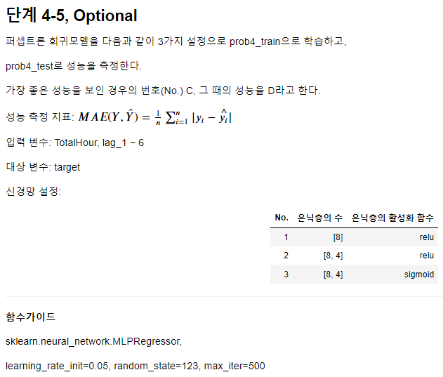

```python
Image('1-4.png')
```

```python
'''
`MLPRegressor` 클래스는 Scikit-learn 라이브러리에서 제공하는 다층 퍼셉트론(MLP) 회귀 모델을 생성하는 클래스입니다.
이 클래스는 회귀 문제를 해결하기 위해 사용됩니다.

### 1. `MLPRegressor` 클래스의 인자

`MLPRegressor` 클래스는 다음과 같은 주요 인자를 가집니다:

- `hidden_layer_sizes`: tuple, default=(100,)
  - 은닉층의 유닛 개수를 정의합니다. 예를 들어 `(100, 50)`이면 두 개의 은닉층이 각각 100, 50개의 유닛을 가집니다.
- `activation`: {'identity', 'logistic', 'tanh', 'relu'}, default='relu'
  - 은닉층의 활성화 함수를 지정합니다. 사용 가능한 함수는 다음과 같습니다:
    - 'identity': f(x) = x
    - 'logistic': 시그모이드 함수, f(x) = 1 / (1 + exp(-x))
    - 'tanh': 하이퍼볼릭 탄젠트 함수, f(x) = tanh(x)
    - 'relu': 렐루 함수, f(x) = max(0, x)
- `solver`: {'lbfgs', 'sgd', 'adam'}, default='adam'
  - 가중치 최적화에 사용되는 알고리즘을 지정합니다.
    - 'lbfgs': L-BFGS 최적화
    - 'sgd': 확률적 경사 하강법
    - 'adam': Adam 최적화
- `alpha`: float, default=0.0001
  - L2 정규화(가중치 감쇠) 항의 계수입니다.
- `batch_size`: int, default='auto'
  - 미니 배치 크기입니다. 'auto'이면 `solver`가 'lbfgs'일 경우 전체 데이터, 'sgd'나 'adam'일 경우 min(200, n_samples)입니다.
- `learning_rate`: {'constant', 'invscaling', 'adaptive'}, default='constant'
  - 학습률 스케줄을 정의합니다.
    - 'constant': 일정한 학습률
    - 'invscaling': 학습률이 1/t로 감소
    - 'adaptive': 학습이 개선되지 않으면 학습률을 감소
- `learning_rate_init`: float, default=0.001
  - 초기 학습률입니다.
- `power_t`: float, default=0.5
  - 'invscaling' 학습률 스케줄에서의 거듭제곱 계수입니다.
- `max_iter`: int, default=200
  - 최대 반복 횟수입니다.
- `shuffle`: bool, default=True
  - 각 에포크마다 데이터를 섞을지 여부를 지정합니다.
- `random_state`: int, RandomState instance, default=None
  - 난수 생성기 시드입니다.
- `tol`: float, default=1e-4
  - 종료 기준을 위한 공차 (tolerance)입니다.
- `verbose`: bool, default=False
  - 진행 상황을 출력할지 여부를 지정합니다.
- `warm_start`: bool, default=False
  - `True`이면 이전 학습 결과를 초기화하지 않고 다음 학습에서 재사용합니다.
- `momentum`: float, default=0.9
  - 'sgd'일 경우 모멘텀 계수입니다.
- `nesterovs_momentum`: bool, default=True
  - 'sgd'일 경우 네스테로프 모멘텀을 사용할지 여부를 지정합니다.
- `early_stopping`: bool, default=False
  - `True`이면 검증 점수가 향상되지 않으면 학습을 조기에 종료합니다.
- `validation_fraction`: float, default=0.1
  - 검증을 위해 훈련 데이터를 분할하는 비율입니다.
      `early_stopping=True`일 때만 사용됩니다.
- `beta_1`: float, default=0.9
  - 'adam' 최적화에서의 1차 모멘트 추정의 감쇠 계수입니다.
- `beta_2`: float, default=0.999
  - 'adam' 최적화에서의 2차 모멘트 추정의 감쇠 계수입니다.
- `epsilon`: float, default=1e-8
  - 'adam' 최적화에서 수치적 안정성을 위한 항입니다.
- `n_iter_no_change`: int, default=10
  - `early_stopping=True`일 때, 검증 점수가 향상되지 않을 경우
      학습을 중지하기 전에 기다리는 에포크 수입니다.
- `max_fun`: int, default=15000
  - 'lbfgs' 솔버에서 허용되는 최대 함수 호출 횟수입니다.

### 2. 리턴값
- `MLPRegressor` 객체 자체를 반환합니다.
    이 객체는 학습된 모델과 그에 따른 메서드들을 포함합니다.

### 3. 주요 속성
- `coefs_`: list, length = n_layers - 1
  - 모델의 가중치 행렬입니다.
- `intercepts_`: list, length = n_layers - 1
  - 모델의 편향 벡터입니다.
- `n_iter_`: int
  - 훈련하는 동안 실행된 반복 횟수입니다.
- `n_layers_`: int
  - 모델의 레이어 수입니다.
- `n_outputs_`: int
  - 출력 레이어의 유닛 수입니다.
- `out_activation_`: string
  - 출력 레이어의 활성화 함수입니다.

### 4. 주요 함수
- `fit(X, y)`: 모델 학습 함수
  - `X`: array-like, shape (n_samples, n_features)
  - `y`: array-like, shape (n_samples,) 또는 (n_samples, n_outputs)
  - 모델을 학습 데이터에 맞게 학습시킵니다.
- `predict(X)`: 예측 함수
  - `X`: array-like, shape (n_samples, n_features)
  - 학습된 모델을 사용하여 입력 데이터 `X`에 대한 예측값을 반환합니다.
- `score(X, y)`: 평가 함수
  - `X`: array-like, shape (n_samples, n_features)
  - `y`: array-like, shape (n_samples,) 또는 (n_samples, n_outputs)
  - 모델의 결정 계수 R^2 점수를 반환합니다.
- `get_params(deep=True)`: 파라미터 반환 함수
  - 모델의 파라미터를 dictionary 형태로 반환합니다.
- `set_params(params)`: 파라미터 설정 함수
  - 모델의 파라미터를 설정합니다.

위 내용은 `MLPRegressor` 클래스의 주요 기능과 사용 방법에 대한 설명입니다.
각 속성과 함수는 Scikit-learn의 공식 문서를 참고하면 더 자세한 정보를 얻을 수 있습니다.
'''
print('')
```

```python
'''
이 코드는 다양한 MLPRegressor(다층 퍼셉트론 회귀모델) 매개변수 설정을 사용하여 모델을 학습시키고,
테스트 데이터와 훈련 데이터에서의 MAE(Mean Absolute Error)를 계산하여 최적의 매개변수를 찾는 작업을 수행합니다.

### 동작 설명

1. 특징 열 목록 생성:
   - MLP 모델에 사용할 특징 열들의 리스트를 만듭니다.
   - `TotalHour`와 `lag_1`부터 `lag_6`까지의 열들이 포함됩니다.

2. 파라미터 설정:
   - MLP 모델을 위한 다양한 매개변수 설정을 정의합니다.
   - 각 설정에는 은닉층의 구조(`hidden_layer_sizes`)와 활성화 함수(`activation`)가 포함됩니다.

3. MAE 저장 리스트 초기화:
   - 테스트 데이터와 훈련 데이터에서의 MAE를 저장할 리스트를 초기화합니다.

4. 모델 학습 및 예측:
   - `for` 루프를 사용하여 각 파라미터 설정에 대해 MLP 모델을 학습시킵니다.
   - `MLPRegressor` 객체를 생성할 때, `param`을 사용하여 사전의 각 매개변수를 언팩(unpack)하여 전달합니다.
   - `reg_mlp.fit(df_prob4_train[X_mlp], df_prob4_train['target'])`를 사용하여 훈련 데이터로 모델을 학습시킵니다.
   - 테스트 데이터와 훈련 데이터에 대해 예측을 수행하고, 그 결과로부터 MAE를 계산하여
       각각 `mae_test`와 `mae_train` 리스트에 추가합니다.
   - 각 파라미터 설정에 대한 MAE 값을 출력합니다.

5. 최적 파라미터 찾기:
   - `mae_test` 리스트에서 가장 작은 MAE 값을 가지는 인덱스를 찾습니다.
   - `np.argmin(mae_test)`는 가장 작은 MAE 값을 가지는 인덱스를 반환하며, 여기서 1을 더하여 1부터 시작하는 인덱스로 만듭니다.
   - `np.min(mae_test)`는 가장 작은 MAE 값을 반환합니다.
   - 첫 번째 반환 값은 최적의 매개변수 설정의 인덱스를 나타내고, 두 번째 반환 값은 해당 설정에서의 MAE 값을 나타냅니다.

### 요약
- 다양한 매개변수 설정으로 MLP 모델을 학습시키고 테스트 데이터와 훈련 데이터에서의 MAE를 계산합니다.
- 가장 낮은 MAE 값을 가지는 최적의 매개변수 설정을 찾습니다.
- 최적의 매개변수 설정의 인덱스와 해당 MAE 값을 출력합니다.
'''

# MLPRegressor의 파라메터 탐색 루틴입니다.


from sklearn.metrics import mean_absolute_error # MAE
from sklearn.neural_network import MLPRegressor

X_mlp = ['TotalHour'] + ['lag_{}'.format(i) for i in range(1, 7)]

print('X_mlp = ', X_mlp)

params = [
    # 은닉층: [8], 활성화함수 :'relu'
    {'hidden_layer_sizes': [8], 'activation': 'relu'},
    # 은닉층: [8, 4], 활성화함수 :'relu'
    {'hidden_layer_sizes': [8, 4], 'activation': 'relu'},
    # 은닉층: [8, 4], 활성화함수 :'sigmoid'
    {'hidden_layer_sizes': [8, 4], 'activation': 'logistic'},
]

mae_test = list()
mae_train = list()

for param in params:
    reg_mlp = MLPRegressor(learning_rate_init=0.05, random_state=123, max_iter=500, **param)
    reg_mlp.fit(df_prob4_train[X_mlp], df_prob4_train['target'])

    mae_test.append(
        mean_absolute_error(df_prob4_test['target'], reg_mlp.predict(df_prob4_test[X_mlp]))
    )

    mae_train.append(
        mean_absolute_error(df_prob4_train['target'], reg_mlp.predict(df_prob4_train[X_mlp]))
    )
    print(param, mae_test[-1], mae_train[-1])

np.argmin(mae_test) + 1, np.min(mae_test)
```

```
X_mlp =  ['TotalHour', 'lag_1', 'lag_2', 'lag_3', 'lag_4', 'lag_5', 'lag_6']
{'hidden_layer_sizes': [8], 'activation': 'relu'} 39.68283671541335 82.07593559886139
{'hidden_layer_sizes': [8, 4], 'activation': 'relu'} 38.57988917988748 80.88441314317811
{'hidden_layer_sizes': [8, 4], 'activation': 'logistic'} 45.59789336930046 75.64436787584789
```

```
(2, 38.57988917988748)
```

# 문제 5

info에서 기온, 풍속, 습도 강수량 데이터에서 이상치를 탐색하고자 한다.

## 단계 5-1

info1에서 기온, 풍속, 습도, 강수량 만을 떼어 weather1 데이터프레임을 만든다.

```python
X_5 = ['기온', '풍속', '습도', '강수량']
df_weather1 = df_info1[X_5].copy()
df_weather1.head()
```

|  | 기온 | 풍속 | 습도 | 강수량 |
| --- | --- | --- | --- | --- |
| 0 | -3.2 | 2.4 | 71 | 0.0 |
| 1 | -4.5 | 1.5 | 77 | 0.0 |
| 2 | -3.9 | 2.6 | 58 | 0.0 |
| 3 | -4.1 | 2.6 | 56 | 0.0 |
| 4 | -4.6 | 2.6 | 60 | 0.0 |

## 단계 5-2

weather1의 기온, 풍속, 습도, 강수량을 표준화 한다.

**함수가이드**

sklearn.preprocessing 제공 기능 활용

문제 지시 사항 외 Default 값 사용

```python
from sklearn.preprocessing import StandardScaler

std_scaler = StandardScaler()

df_weather1[X_5] = std_scaler.fit_transform(df_weather1[X_5])
df_weather1.head()
```

|  | 기온 | 풍속 | 습도 | 강수량 |
| --- | --- | --- | --- | --- |
| 0 | -2.085903 | 0.289680 | 0.039195 | -0.233447 |
| 1 | -2.227830 | -0.483098 | 0.300129 | -0.233447 |
| 2 | -2.162325 | 0.461409 | -0.526162 | -0.233447 |
| 3 | -2.184160 | 0.461409 | -0.613140 | -0.233447 |
| 4 | -2.238748 | 0.461409 | -0.439184 | -0.233447 |

## 단계 5-3

DBSCAN 군집화를 입실론(epsilon) 반경, 즉 이웃으로 간주되기 위한 최대거리 0.5,

중심점(Core Point)이 되기 위한 최소 이웃의 수 7(자기 자신을 포함한다.) 로 설정한다.

weather1에 DBSCAN 결과에서 소속 군집이 없는 샘플들을 이상점으로 간주한다.

이상점 여부를 파생변수 outlier_dbscan로 하여 weather1에 추가한다. (소속 군집이 있으면: False, 없으면 True)

입력변수: 기온, 풍속, 습도, 강수량

**함수가이드**

sklearn.cluster.DBSCAN, algorithm=’brute’

문제 지시 사항 외 Default 값 사용

```python
'''
`DBSCAN` (Density-Based Spatial Clustering of Applications with Noise) 클래스는
Scikit-learn 라이브러리에서 제공하는 밀도 기반 군집화 알고리즘입니다.
`DBSCAN`은 밀도가 높은 데이터 포인트의 영역을 클러스터로 식별하고, 밀도가 낮은 포인트는 이상치로 간주합니다.

### 1. `DBSCAN` 클래스의 인자
- `eps`: float, default=0.5
  - 두 포인트가 같은 클러스터에 속하기 위해 최대 허용 거리입니다.
- `min_samples`: int, default=5
  - 한 클러스터 내에서 포인트가 핵심 포인트로 간주되기 위해 필요한 최소 샘플 수입니다.
- `metric`: string, or callable, default='euclidean'
  - 포인트 간 거리 계산에 사용되는 거리 측정 방법입니다. 기본값은 'euclidean' 거리입니다.
- `metric_params`: dict, default=None
  - 거리 측정 방법에 추가적으로 전달할 파라미터입니다.
- `algorithm`: {'auto', 'ball_tree', 'kd_tree', 'brute'}, default='auto'
  - 최근접 이웃을 계산할 때 사용할 알고리즘입니다. 'auto'는 데이터의 특성에 따라 최적의 알고리즘을 선택합니다.
- `leaf_size`: int, default=30
  - `BallTree` 또는 `KDTree` 알고리즘에서 사용하는 리프의 크기입니다. 리프의 크기는 트리 생성과 쿼리 속도에 영향을 미칩니다.
- `p`: float, default=None
  - `minkowski` 거리 계산에 사용할 거리 차수입니다. `metric='minkowski'`인 경우에만 사용됩니다.
- `n_jobs`: int, default=None
  - 병렬로 실행할 작업 수입니다. `-1`은 모든 프로세서를 사용합니다. `None`이면 단일 작업만 사용합니다.

### 2. 리턴값
- `DBSCAN` 객체 자체를 반환합니다. 이 객체는 학습된 모델과 그에 따른 메서드들을 포함합니다.

### 3. 주요 속성
- `core_sample_indices_`: array, shape (n_core_samples,)
  - 핵심 샘플의 인덱스입니다.
- `components_`: array, shape (n_core_samples, n_features)
  - 핵심 샘플의 배열입니다.
- `labels_`: array, shape (n_samples,)
  - 각 샘플의 클러스터 레이블입니다. 클러스터에 속하지 않는 샘플은 레이블 -1로 지정됩니다.

### 4. 주요 함수

- `fit(X, y=None, sample_weight=None)`: 모델 학습 함수
  - `X`: array-like, shape (n_samples, n_features)
    - 학습 데이터입니다.
  - `y`: Ignored
    - 타겟 값은 무시됩니다.
  - `sample_weight`: array-like, shape (n_samples,), default=None
    - 각 샘플의 가중치입니다.
- `fit_predict(X, y=None, sample_weight=None)`: 모델 학습 및 예측 함수
  - `X`: array-like, shape (n_samples, n_features)
    - 학습 데이터입니다.
  - `y`: Ignored
    - 타겟 값은 무시됩니다.
  - `sample_weight`: array-like, shape (n_samples,), default=None
    - 각 샘플의 가중치입니다.
  - 학습된 모델을 사용하여 입력 데이터 `X`에 대한 클러스터 레이블을 반환합니다.
- `get_params(deep=True)`: 파라미터 반환 함수
  - 모델의 파라미터를 dictionary 형태로 반환합니다.
- `set_params(params)`: 파라미터 설정 함수
  - 모델의 파라미터를 설정합니다.
- `fit_transform(X, y=None, sample_weight=None)`: 모델 학습 및 변환 함수
  - `X`: array-like, shape (n_samples, n_features)
    - 학습 데이터입니다.
  - `y`: Ignored
    - 타겟 값은 무시됩니다.
  - `sample_weight`: array-like, shape (n_samples,), default=None
    - 각 샘플의 가중치입니다.
  - 학습된 모델을 사용하여 입력 데이터 `X`를 클러스터 레이블로 변환합니다.
'''
print('')
```

```python
'''
이 코드는 기온, 풍속, 습도, 강수량이라는 네 가지 기상 요소를 기반으로
DBSCAN(밀도 기반 클러스터링) 알고리즘을 사용하여 데이터를 클러스터링하는 과정을 보여줍니다.

### 동작 설명

1. 특징 열 선택:
   - `df_info1` 데이터프레임에서 `기온`, `풍속`, `습도`, `강수량` 열을 선택하여 `df_weather1`이라는 새로운 데이터프레임을 만듭니다.
   - `copy()` 메서드를 사용하여 원본 데이터프레임을 수정하지 않도록 합니다.

2. 표준화(스케일링):
   - `StandardScaler` 객체를 생성합니다.
   - `fit_transform` 메서드를 사용하여 선택된 기상 요소 열을 표준화합니다.
   - 표준화는 데이터의 평균을 0, 표준편차를 1로 맞추어 변환합니다.

3. DBSCAN 객체 생성 및 설정:
   - DBSCAN 객체를 생성하고, 주요 매개변수를 설정합니다.
     - `eps = 0.5`: 이웃으로 간주되기 위한 최대 거리(반경).
     - `min_samples = 7`: 중심점(Core Point)이 되기 위한 최소 이웃의 수. 최소 6개의 이웃과 자기 자신으로 구성됩니다.
     - `algorithm = 'brute'`: 거리 계산을 위한 알고리즘. 'brute'는 모든 쌍의 거리를 계산합니다.

4. DBSCAN 클러스터링 수행:
   - 표준화된 기상 요소 데이터를 사용하여 DBSCAN 클러스터링을 수행합니다.
   - `fit` 메서드를 사용하여 데이터를 클러스터링하고 각 데이터 포인트에 클러스터 레이블을 할당합니다.

### DBSCAN (밀도 기반 클러스터링) 개요

DBSCAN(Density-Based Spatial Clustering of Applications with Noise)은 밀도 기반 클러스터링 알고리즘으로,
데이터 포인트의 밀도에 따라 클러스터를 형성합니다. 주요 개념은 다음과 같습니다:
- Epsilon (eps): 주어진 포인트에서 이웃으로 간주되기 위한 최대 거리.
- Min Samples (min_samples): 중심점이 되기 위한 최소 이웃의 수. (자기 자신 포함)
- Core Point: 이웃이 min_samples 이상인 포인트.
- Border Point: 이웃이 min_samples 미만이지만 Core Point의 이웃인 포인트.
- Noise: 어떤 클러스터에도 속하지 않는 포인트.

이 알고리즘은 밀도가 높은 지역을 클러스터로 형성하고, 밀도가 낮은 지역을 노이즈로 간주합니다.
'''

from sklearn.cluster import DBSCAN

dbscan = DBSCAN(
    # 입실론(epsilon) 반경, 즉 이웃으로 간주되기 위한 최대거리 0.5,
    eps = 0.5,
    # 중심점(Core Point)이 되기 위한 최소 이웃의 수 7(자기 자신을 포함한다.)
    min_samples = 7,
    algorithm='brute'
)
# predict에서 train과 동일한 샘플이다라고 판단할 식별정보는 없습니다.
# 자기자신에 대한 개념이 있는 모델은, predict를 지원하지 않습니다.
# 대신 fit_predict만을 지원합니다.

dbscan.fit(df_weather1[X_5])
```

```
DBSCAN(algorithm='brute', eps=0.5, leaf_size=30, metric='euclidean',
       metric_params=None, min_samples=7, n_jobs=None, p=None)
```

```python
'''
이 코드는 DBSCAN 클러스터링 알고리즘을 사용하여 이상치(outlier)를 식별하고,
그 결과를 `df_weather1` 데이터프레임에 추가하는 작업을 수행합니다.

### 동작 설명

1. DBSCAN 클러스터 레이블을 사용하여 이상치 식별:
   - `dbscan.labels_`는 DBSCAN 알고리즘이 데이터 포인트에 할당한  클러스터 레이블을 포함하는 배열입니다.
   - DBSCAN에서 `labels_`가 `-1`인 데이터 포인트는 어떤 클러스터에도 속하지 않는 것으로 간주되며,
       이는 이상치(outlier)를 의미합니다.
   - `dbscan.labels_ == -1`은 레이블이 `-1`인 데이터 포인트를 `True`로,
       그렇지 않은 포인트를 `False`로 변환하는 Boolean 배열을 만듭니다.
   - 이 Boolean 배열을 `df_weather1` 데이터프레임의 새로운 열 `outlier_dbscan`에 추가합니다.
   - `outlier_dbscan` 열은 각 데이터 포인트가 이상치인지 아닌지를 나타내는 Boolean 값 (`True` 또는 `False`)을 포함하게 됩니다.

2. 이상치의 수 계산:
   - `df_weather1['outlier_dbscan']`는 `True`와 `False` 값을 포함하는 열입니다.
   - `sum()` 메서드는 이 열에서 `True` 값의 개수를 합산합니다.
   - Boolean 값에서 `True`는 `1`로, `False`는 `0`으로 간주되므로, `sum()` 메서드는 이상치의 수를 반환합니다.

### 요약
- `df_weather1['outlier_dbscan'] = dbscan.labels_ == -1`:
  - DBSCAN 알고리즘의 결과에서 레이블이 `-1`인 데이터를 식별하여, 이를 새로운 열 `outlier_dbscan`에 Boolean 값으로 저장합니다.
      `True`는 이상치를, `False`는 정상 데이터를 나타냅니다.
- `df_weather1['outlier_dbscan'].sum()`:
  - `outlier_dbscan` 열에서 `True` 값의 개수를 세어, 이상치의 총 개수를 계산합니다.

이 과정의 최종 결과는 `df_weather1` 데이터프레임에 이상치 여부를 나타내는 열이 추가되고,
전체 데이터 중에서 이상치로 식별된 데이터 포인트의 수를 알 수 있게 됩니다.
'''

df_weather1
```

|  | 기온 | 풍속 | 습도 | 강수량 |
| --- | --- | --- | --- | --- |
| 0 | -2.085903 | 0.289680 | 0.039195 | -0.233447 |
| 1 | -2.227830 | -0.483098 | 0.300129 | -0.233447 |
| 2 | -2.162325 | 0.461409 | -0.526162 | -0.233447 |
| 3 | -2.184160 | 0.461409 | -0.613140 | -0.233447 |
| 4 | -2.238748 | 0.461409 | -0.439184 | -0.233447 |
| ... | ... | ... | ... | ... |
| 6163 | 0.632553 | 1.320051 | 0.648042 | 0.744500 |
| 6164 | 0.687140 | 1.835237 | 0.343618 | 0.744500 |
| 6165 | 0.687140 | 1.921101 | 0.256640 | 0.744500 |
| 6166 | 0.665305 | 0.375545 | 0.387107 | 0.744500 |
| 6167 | 0.665305 | 0.375545 | 0.387107 | 0.744500 |

6168 rows × 4 columns

```python
# labels_ 에 군집화 결과가 들어 있습니다.
df_weather1['outlier_dbscan'] = dbscan.labels_ == -1
df_weather1['outlier_dbscan'].sum()
```

```
210
```

## 단계 5-4

IsolationForest를 사용하여 weather1의 이상점을 탐색한다.

학습시 bootstrapping은 하지 않고, 트리의 수는 30개를 사용한다.

IsolationForest으로 탐지한 이상점 여부는 파생변수 outlier_isof로 하여 weather1에 추가한다.

(이상치라면 True, 아니면 False)

입력변수: 기온, 풍속, 습도, 강수량

**함수가이드**

sklearn.ensemble.IsolationForest, random_state=123, contamination=’auto’, behaviour=’auto’

문제 지시 사항 외 Default 값 사용

```python
'''
`IsolationForest` 클래스는 Scikit-learn 라이브러리에서 제공하는 이상치 탐지 알고리즘 중 하나입니다.
`IsolationForest`는 주로 이상치 탐지(Anomaly Detection)에 사용되며, 데이터를 분리하는 방식으로 작동합니다.
이 알고리즘은 데이터의 임의의 하위 집합을 선택하고 무작위로 선택된 특성을 사용하여 데이터를 분할합니다.
이상치는 정상 데이터보다 더 적은 분할로 쉽게 분리됩니다.

### 1. `IsolationForest` 클래스의 인자
- `n_estimators`: int, default=100
  - 모델에서 사용할 트리의 수입니다.
- `max_samples`: int or float, default='auto'
  - 각 트리에서 사용할 샘플의 최대 수입니다.
  - `int`: 사용할 샘플의 수.
  - `float`: 데이터셋의 비율 (0 < max_samples <= 1).
  - 'auto': min(256, n_samples).
- `contamination`: 'auto', float, default='auto'
  - 데이터셋에 있는 이상치의 비율을 지정합니다.
  - 'auto': 0.1로 설정됩니다.
  - float: 0에서 0.5 사이의 값이어야 합니다.
- `max_features`: int or float, default=1.0
  - 각 트리에서 사용할 특성의 최대 수입니다.
  - `int`: 사용할 특성의 수.
  - `float`: 특성의 비율 (0 < max_features <= 1).
- `bootstrap`: bool, default=False
  - True로 설정하면 부트스트래핑을 사용합니다. 즉, 샘플을 중복 허용하여 선택합니다.
- `n_jobs`: int, default=None
  - 병렬로 실행할 작업 수입니다. `-1`은 모든 프로세서를 사용합니다. `None`이면 단일 작업만 사용합니다.
- `random_state`: int, RandomState instance or None, default=None
  - 난수 생성기 시드입니다.
- `verbose`: int, default=0
  - 디버깅 출력을 활성화합니다.
- `warm_start`: bool, default=False
  - True로 설정하면 기존 모델에 추정기를 추가하여 학습합니다.

### 2. 리턴값
- `IsolationForest` 객체 자체를 반환합니다. 이 객체는 학습된 모델과 그에 따른 메서드들을 포함합니다.

### 3. 주요 속성
- `estimators_`: list of DecisionTreeClassifier
  - 학습된 각 트리 모델입니다.
- `max_samples_`: int
  - 각 트리에서 사용된 샘플의 수입니다.
- `n_features_in_`: int
  - 입력 데이터의 특성 수입니다.
- `feature_names_in_`: ndarray of shape (n_features_in_,)
  - 입력 데이터의 특성 이름입니다.

### 4. 주요 함수
- `fit(X, y=None, sample_weight=None)`: 모델 학습 함수
  - `X`: array-like, shape (n_samples, n_features)
    - 학습 데이터입니다.
  - `y`: Ignored
    - 타겟 값은 무시됩니다.
  - `sample_weight`: array-like, shape (n_samples,), default=None
    - 각 샘플의 가중치입니다.
  - 학습 데이터를 사용하여 `IsolationForest` 모델을 학습시킵니다.
- `predict(X)`: 예측 함수
  - `X`: array-like, shape (n_samples, n_features)
    - 예측할 데이터입니다.
  - 각 샘플에 대한 예측값을 반환합니다. 1은 정상 샘플,
      -1은 이상치 샘플을 나타냅니다.
- `fit_predict(X, y=None, sample_weight=None)`: 학습 및 예측 함수
  - `X`: array-like, shape (n_samples, n_features)
    - 학습 및 예측할 데이터입니다.
  - 학습 데이터를 사용하여 모델을 학습시키고, 각 샘플에 대한 예측값을 반환합니다.
- `decision_function(X)`: 결정 함수
  - `X`: array-like, shape (n_samples, n_features)
    - 평가할 데이터입니다.
  - 각 샘플에 대한 이상치 점수를 반환합니다.
      점수가 낮을수록 이상치일 가능성이 높습니다.
- `score_samples(X)`: 샘플 점수 함수
  - `X`: array-like, shape (n_samples, n_features)
    - 평가할 데이터입니다.
  - 각 샘플에 대한 음의 이상치 점수를 반환합니다. 결정 함수의 반대입니다.
- `get_params(deep=True)`: 파라미터 반환 함수
  - 모델의 파라미터를 dictionary 형태로 반환합니다.
- `set_params(params)`: 파라미터 설정 함수
  - 모델의 파라미터를 설정합니다.
'''
print('')
```

```python
'''
이 코드는 Isolation Forest 알고리즘을 사용하여 데이터에서 이상치(outlier)를 탐지하는 과정을 수행합니다.

### 동작 설명

1. Isolation Forest 모델 생성:
   - `IsolationForest`는 sklearn.ensemble 모듈에서 제공하는 이상치 탐지 모델입니다.
   - `n_estimators=30`은 30개의 결정 트리를 사용하여 모델을 구성함을 의미합니다.
   - `bootstrap=False`는 부트스트래핑을 사용하지 않음을 의미합니다.
       즉, 원본 데이터를 그대로 사용하여 트리를 학습합니다.
   - `random_state=123`은 난수 발생기의 상태를 고정하여 결과의 재현성을 보장합니다.
   - `contamination='auto'`는 이상치의 비율을 자동으로 결정하게 합니다.
   - `behaviour='auto'`는 사이킷런의 버전 호환성을 위해 사용될 수 있지만, 최신 버전에서는 불필요할 수 있습니다.

2. Isolation Forest 모델 학습:
   - `fit` 메서드는 모델을 데이터에 맞추어 학습시킵니다.
   - `df_weather1[X_5]`는 `df_weather1` 데이터프레임의 `X_5` 열들, 즉 ['기온', '풍속', '습도', '강수량']를 학습 데이터로 사용합니다.
   - Isolation Forest는 각 데이터 포인트를 분리하는 데 필요한 경로 길이를 기반으로 이상치를 탐지합니다.
       경로가 짧을수록 이상치일 가능성이 높습니다.

### 요약
- Isolation Forest 모델을 설정하고, 이를 사용하여 데이터의 이상치를 탐지합니다.
- `n_estimators=30`은 30개의 트리를 사용하여 모델을 학습합니다.
- `bootstrap=False`는 부트스트래핑 없이 원본 데이터를 사용하여 학습합니다.
- `random_state=123`은 난수 발생기를 고정하여 재현성을 보장합니다.
- `contamination='auto'`는 이상치 비율을 자동으로 결정합니다.
- `fit(df_weather1[X_5])`는 `df_weather1` 데이터프레임의 `X_5` 열들로 모델을 학습시킵니다.

이렇게 학습된 Isolation Forest 모델은 이후에 새로운 데이터에 대해 이상치 여부를 예측할 수 있게 됩니다.
'''

from sklearn.ensemble import IsolationForest

isof = IsolationForest(
    n_estimators=30, # 트리의 수는 30개를 사용한다.
    bootstrap=False, # 학습시 bootstrapping은 하지 않고,
    random_state=123, contamination='auto', behaviour='auto'
)

isof.fit(df_weather1[X_5])
```

```
IsolationForest(behaviour='auto', bootstrap=False, contamination='auto',
                max_features=1.0, max_samples='auto', n_estimators=30,
                n_jobs=None, random_state=123, verbose=0, warm_start=False)
```

```python
'''
코드는 Isolation Forest 모델을 사용하여 데이터에서 이상치를 탐지하고, 그 결과를 데이터프레임에 저장한 후 이상치의 개수를 계산합니다.

### 동작 설명

1. Isolation Forest 예측:
   - `isof.predict` 메서드는 학습된 Isolation Forest 모델을 사용하여 `df_weather1[X_5]`의 각 데이터 포인트에 대해 이상치 여부를 예측합니다.
   - `df_weather1[X_5]`는 `df_weather1` 데이터프레임에서 '기온', '풍속', '습도', '강수량' 열을 포함한 부분입니다.
   - `predict` 메서드는 각 데이터 포인트에 대해 1 또는 -1을 반환합니다. 1은 정상 데이터를 의미하고, -1은 이상치를 의미합니다.

2. 이상치 여부 저장:
   - `isof.predict(df_weather1[X_5]) == -1`는 예측 결과가 -1인지 여부를 체크하여 불리언 배열을 만듭니다.
   - `df_weather1['outlier_isof']`에 이 불리언 배열을 저장합니다.
       즉, 각 데이터 포인트가 이상치인 경우 `True`, 정상인 경우 `False`가 저장됩니다.

3. 이상치 개수 계산:
   - `df_weather1['outlier_isof']` 열의 `True` 값의 개수를 계산합니다.
   - 불리언 값은 `True`가 1, `False`가 0으로 간주되기 때문에, `sum` 메서드를 사용하여 `True` 값의 개수를 계산할 수 있습니다.
   - 이 값은 데이터프레임에서 탐지된 이상치의 총 개수를 의미합니다.

### 요약
- `isof.predict(df_weather1[X_5])`는 Isolation Forest 모델을 사용하여 데이터에서 이상치 여부를 예측합니다.
- 예측 결과가 -1인 경우를 `True`로 변환하여 `df_weather1['outlier_isof']` 열에 저장합니다.
- `df_weather1['outlier_isof'].sum()`은 데이터프레임에서 탐지된 이상치의 총 개수를 계산합니다.

이 코드는 전체 데이터에서 이상치가 몇 개인지 확인하는 데 유용하며, 이후 분석이나 전처리 단계에서 이 정보를 사용할 수 있습니다.
'''

df_weather1
```

|  | 기온 | 풍속 | 습도 | 강수량 | outlier_dbscan |
| --- | --- | --- | --- | --- | --- |
| 0 | -2.085903 | 0.289680 | 0.039195 | -0.233447 | False |
| 1 | -2.227830 | -0.483098 | 0.300129 | -0.233447 | False |
| 2 | -2.162325 | 0.461409 | -0.526162 | -0.233447 | False |
| 3 | -2.184160 | 0.461409 | -0.613140 | -0.233447 | False |
| 4 | -2.238748 | 0.461409 | -0.439184 | -0.233447 | False |
| ... | ... | ... | ... | ... | ... |
| 6163 | 0.632553 | 1.320051 | 0.648042 | 0.744500 | False |
| 6164 | 0.687140 | 1.835237 | 0.343618 | 0.744500 | True |
| 6165 | 0.687140 | 1.921101 | 0.256640 | 0.744500 | True |
| 6166 | 0.665305 | 0.375545 | 0.387107 | 0.744500 | True |
| 6167 | 0.665305 | 0.375545 | 0.387107 | 0.744500 | True |

6168 rows × 5 columns

```python
df_weather1['outlier_isof'] = isof.predict(df_weather1[X_5]) == -1
df_weather1['outlier_isof'].sum()
```

```
1108
```

```python
'''
코드는 Isolation Forest 모델의 `decision_function` 메서드와 `predict` 메서드를 사용하여 이상치 탐지의 일관성을 확인하는 작업을 수행합니다.

### 동작 설명
1. Decision Function 결과 계산:
   - `isof.decision_function(df_weather1[X_5])`는 Isolation Forest 모델의 결정 함수 값을 반환합니다.
   - 결정 함수 값은 각 데이터 포인트의 이상치 점수를 의미합니다. 값이 낮을수록 이상치일 가능성이 높습니다.

2. Decision Function 결과 비교:
   isof.decision_function(df_weather1[X_5]) < 0
   - 결정 함수 값이 0보다 작은지 여부를 확인합니다.
   - 이는 이상치 점수가 0보다 낮은 경우 이상치로 간주하기 위한 조건입니다.
   - 결과는 불리언 배열로, 각 데이터 포인트에 대해 결정 함수 값이 0보다 작은 경우 `True`, 그렇지 않은 경우 `False`입니다.

3. Predict 결과 계산:
   - `isof.predict(df_weather1[X_5])`는 Isolation Forest 모델을 사용하여 각 데이터 포인트가 이상치인지 정상인지 예측합니다.
   - 예측 값은 1(정상) 또는 -1(이상치)입니다.

4. Predict 결과 비교:
   - 예측 값이 -1인지 여부를 확인합니다.
   - 이는 각 데이터 포인트가 이상치인지 여부를 불리언 배열로 나타냅니다. 이상치인 경우 `True`, 그렇지 않은 경우 `False`입니다.

5. Decision Function 결과와 Predict 결과의 불일치 계산:
   - `!=` 연산자를 사용하여 결정 함수 결과와 예측 결과의 불일치를 확인합니다.
   - 두 불리언 배열을 비교하여 값이 다르면 `True`, 같으면 `False`를 반환합니다.
   - 결과는 불일치 여부를 나타내는 불리언 배열입니다.

6. 불일치 개수 계산:
   - 불일치 여부를 나타내는 불리언 배열에서 `True` 값의 개수를 계산합니다.
   - `sum` 메서드는 `True` 값의 개수를 합산하여, 결정 함수와 예측 결과가 불일치한 데이터 포인트의 총 개수를 반환합니다.

### 요약
- `isof.decision_function(df_weather1[X_5]) < 0`와 `isof.predict(df_weather1[X_5]) == -1`의 결과를 비교하여 불일치 여부를 확인합니다.
- 결정 함수 값이 0보다 작은 경우와 예측 값이 -1인 경우가 일치하지 않는 데이터 포인트의 개수를 계산합니다.
- 이 코드는 Isolation Forest 모델의 결정 함수와 예측 결과의 일관성을 검증하기 위한 것입니다.
    불일치가 발생하면 모델의 이상치 탐지 결과에 문제가 있을 수 있습니다.
'''

((isof.decision_function(df_weather1[X_5]) < 0) != (isof.predict(df_weather1[X_5]) == -1)).sum()
```

```
0
```

## 단계 5-5

LocalOutlierFactor를 사용하여 weather1의 이상점을 탐색한다.

관찰할 주변의 샘플은 10개이다. 그리고, 샘플간의 거리는 유클리디언 거리를 사용한다.

주어진 데이터셋에 대해서만 이상치 판별을 위해 모델을 만들도록 설정한다.

LocalOutlierFactor로 탐지한 이상 여부를 outlier_lof로 하여 weather1에 추가한다.

입력변수: 기온, 풍속, 습도, 강수량

**함수가이드**

sklearn.neighbors.LocalOutlierFactor, contamination=’auto’

```python
'''
코드는 `LocalOutlierFactor` (LOF) 알고리즘을 사용하여 데이터 프레임 `df_weather1`의 이상치를 탐지하는 과정을 보여줍니다.

### 동작 설명
1. LocalOutlierFactor 객체 생성:
   - `LocalOutlierFactor` 객체 `lof`를 생성합니다.
   - `n_neighbors=10`: 각 데이터 포인트의 이상치를 평가할 때 고려할 이웃의 수를 10개로 설정합니다.
   - `metric='euclidean'`: 유클리드 거리를 사용하여 데이터 포인트 간의 거리를 계산합니다.
   - `novelty=False`: 모델을 주어진 데이터셋에 대해서만 훈련하고 이상치를 탐지합니다. 새로운 데이터를 예측하지 않습니다.
   - `contamination='auto'`: 데이터셋에서 자동으로 이상치의 비율을 추정합니다.

2. LOF 모델을 사용하여 이상치 탐지:
   - `lof.fit_predict(df_weather1[X_5])`:
     - `df_weather1[X_5]`에 있는 데이터 포인트에 대해 LOF 모델을 훈련하고 예측합니다.
     - `fit_predict` 메서드는 각 데이터 포인트가 정상인지 이상치인지를 예측합니다.
     - 결과는 1 (정상) 또는 -1 (이상치)입니다.
   - `== -1`:
     - 예측 결과가 -1인 데이터 포인트를 이상치로 간주합니다.
     - 결과는 불리언 배열로, 각 데이터 포인트에 대해 이상치인 경우 `True`, 그렇지 않은 경우 `False`입니다.
   - `df_weather1['outlier_lof']`에 이상치 여부를 저장합니다.

3. 이상치 개수 계산:
   df_weather1['outlier_lof'].sum()
   - `df_weather1['outlier_lof']` 열에서 `True` 값의 개수를 합산합니다.
   - 이는 데이터 프레임 `df_weather1`에서 탐지된 이상치의 총 개수를 반환합니다.

### 요약
- `LocalOutlierFactor` 객체를 생성하고, LOF 알고리즘을 사용하여 데이터 프레임 `df_weather1`의 이상치를 탐지합니다.
- `fit_predict` 메서드를 사용하여 각 데이터 포인트가 이상치인지 여부를 예측합니다.
- 예측 결과가 -1인 경우를 이상치로 간주하고, 이를 불리언 배열로 저장합니다.
- 데이터 프레임에서 탐지된 이상치의 총 개수를 계산하여 반환합니다.
'''

from sklearn.neighbors import LocalOutlierFactor

lof = LocalOutlierFactor(
    n_neighbors=10, # 관찰할 주변의 샘플은 10개이다.
    metric='euclidean', # 그리고, 샘플간의 거리는 유클리디언 거리를 사용한다.
    # 주어진 데이터셋에 대해서만 이상치 판별을 위해 모델을 만들도록 설정한다.
    novelty=False,
    contamination='auto'
)

df_weather1['outlier_lof'] = lof.fit_predict(df_weather1[X_5]) == -1
df_weather1
```

|  | 기온 | 풍속 | 습도 | 강수량 | outlier_dbscan | outlier_isof | outlier_lof |
| --- | --- | --- | --- | --- | --- | --- | --- |
| 0 | -2.085903 | 0.289680 | 0.039195 | -0.233447 | False | False | False |
| 1 | -2.227830 | -0.483098 | 0.300129 | -0.233447 | False | False | False |
| 2 | -2.162325 | 0.461409 | -0.526162 | -0.233447 | False | False | False |
| 3 | -2.184160 | 0.461409 | -0.613140 | -0.233447 | False | False | False |
| 4 | -2.238748 | 0.461409 | -0.439184 | -0.233447 | False | False | False |
| ... | ... | ... | ... | ... | ... | ... | ... |
| 6163 | 0.632553 | 1.320051 | 0.648042 | 0.744500 | False | True | False |
| 6164 | 0.687140 | 1.835237 | 0.343618 | 0.744500 | True | True | False |
| 6165 | 0.687140 | 1.921101 | 0.256640 | 0.744500 | True | True | False |
| 6166 | 0.665305 | 0.375545 | 0.387107 | 0.744500 | True | False | False |
| 6167 | 0.665305 | 0.375545 | 0.387107 | 0.744500 | True | False | False |

6168 rows × 7 columns

```python
df_weather1['outlier_lof'].sum()
```

```
83
```

```python
'''
`LocalOutlierFactor` (LOF) 클래스는 Scikit-learn 라이브러리에서 제공하는 이상치 탐지 알고리즘 중 하나입니다.
LOF는 각 데이터 포인트의 국지적인 밀도를 기반으로 이상치를 탐지합니다.
이 알고리즘에서 중요한 두 가지 속성은 `negative_outlier_factor_`와 `offset_`입니다.

### 1. `negative_outlier_factor_` 속성
- 정의: `negative_outlier_factor_` 속성은 각 데이터 포인트의 LOF 점수를 부호를 바꾸어 저장한 배열입니다.
- 값: LOF 점수는 원래 클수록 정상적인 포인트를 의미하며, 값이 작을수록 (즉, 음수 값의 절대값이 클수록) 이상치일 가능성이 높습니다.
- 용도: 이 속성은 각 데이터 포인트가 얼마나 이상치에 가까운지 나타냅니다.
    값이 -1에 가까울수록 정상에 가깝고, 값이 작을수록 이상치일 가능성이 높습니다.

### 2. `offset_` 속성
- 정의: `offset_` 속성은 이상치와 정상 데이터를 구분하는 기준점을 의미합니다.
- 값: `offset_`은 `contamination` 파라미터에 의해 결정됩니다.
    `contamination`은 데이터셋에서 이상치의 예상 비율을 지정하는 파라미터입니다.
- 용도: `offset_`은 `negative_outlier_factor_` 값과 비교하여 데이터 포인트가 이상치인지 아닌지를 판단하는 데 사용됩니다.

### 3. `negative_outlier_factor_`와 `offset_` 사이의 관계
`negative_outlier_factor_`와 `offset_`의 관계는 데이터 포인트를 이상치와 정상 데이터로 분류하는 데 핵심적입니다.

- 이상치 판별 기준:
  - `negative_outlier_factor_` 값이 `offset_`보다 작으면 해당 데이터 포인트는 이상치로 간주됩니다.
  - `negative_outlier_factor_` 값이 `offset_`보다 크거나 같으면 해당 데이터 포인트는 정상 데이터로 간주됩니다.

아래 예제에서 `negative_outlier_factor_` 속성은 각 데이터 포인트의 LOF 점수를 부호를 바꾸어 나타낸 배열을 출력합니다.
`offset_` 속성은 이상치와 정상 데이터를 구분하는 기준값을 나타냅니다.
`fit_predict` 메서드는 각 데이터 포인트가 이상치인지 정상 데이터인지를 나타내는 예측값을 반환합니다.

### 요약
- `negative_outlier_factor_`는 각 데이터 포인트의 LOF 점수를 부호를 바꾸어 저장한 속성입니다.
    값이 작을수록 이상치일 가능성이 높습니다.
- `offset_`은 이상치와 정상 데이터를 구분하는 기준점을 나타내며, `contamination` 파라미터에 의해 결정됩니다.
- 두 속성은 함께 사용되어 데이터 포인트를 이상치와 정상 데이터로 분류합니다.
    `negative_outlier_factor_` 값이 `offset_`보다 작으면 해당 데이터 포인트는 이상치로 간주됩니다.
'''

### 예제
from sklearn.neighbors import LocalOutlierFactor

# 예제 데이터 생성
X = [[-1.1], [0.2], [101.1], [0.3]]

# LOF 모델 생성 및 학습
clf = LocalOutlierFactor(n_neighbors=2)
clf.fit(X)

# negative_outlier_factor_ 값 확인
print(clf.negative_outlier_factor_)

# offset_ 값 확인
print(clf.offset_)

# 이상치 판별
predictions = clf.fit_predict(X)
print(predictions)

print(clf.negative_outlier_factor_ < clf.offset_)
```

```
[ -0.98214286  -1.03703704 -73.36970899  -0.98214286]
-51.66990740371985
[ 1  1 -1  1]
[False False  True False]
```

```python
'''
코드는 `LocalOutlierFactor` (LOF) 모델에서 이상치 판별에 사용된 두 가지 기준의 일치 여부를 확인하는 과정을 보여줍니다.
각각의 기준에 의해 판별된 이상치가 일치하지 않는 경우의 수를 계산합니다.

### 동작 설명
1. LOF 모델 훈련 및 예측:
   - `lof.fit_predict(df_weather1[X_5])`:
     - `df_weather1[X_5]` 데이터에 대해 LOF 모델을 훈련하고 예측합니다.
     - 결과는 각 데이터 포인트가 정상인지 이상치인지를 나타내는 배열입니다. 1은 정상, -1은 이상치를 의미합니다.

2. Negative Outlier Factor 및 Offset 계산:
   - `lof.negative_outlier_factor_`:
     - LOF 모델이 각 데이터 포인트에 대해 계산한 negative outlier factor(NOF)를 반환합니다.
         NOF 값이 작을수록 해당 데이터 포인트가 더 이상치에 가까움을 나타냅니다.
   - `lof.offset_`:
     - LOF 모델이 사용하는 기준값 (offset)입니다. NOF 값이 이 offset 값보다 작으면 해당 데이터 포인트를  이상치로 간주합니다.

3. 이상치 판별 기준 비교:
   - `lof.negative_outlier_factor_ < lof.offset_`:
     - 각 데이터 포인트의 NOF 값이 offset 값보다 작은지 여부를 판단합니다.
     - 결과는 불리언 배열로, `True`는 이상치, `False`는 정상 데이터를 의미합니다.
   - `lof.fit_predict(df_weather1[X_5]) == -1`:
     - `fit_predict` 메서드에 의해 예측된 이상치 여부를 나타내는 불리언 배열입니다.
     - `True`는 이상치, `False`는 정상 데이터를 의미합니다.

4. 두 기준의 불일치 여부 계산:
   - `(lof.negative_outlier_factor_ < lof.offset_) != (lof.fit_predict(df_weather1[X_5]) == -1)`:
     - 두 기준에 의해 판별된 이상치 여부가 서로 다른지 여부를 판단합니다.
     - 결과는 불리언 배열로, `True`는 두 기준이 불일치하는 데이터 포인트를 의미합니다.

5. 불일치한 데이터 포인트의 개수 계산:
   - `.sum()`:
     - 불리언 배열에서 `True` 값의 개수를 합산합니다.
     - 이는 두 기준이 불일치하는 데이터 포인트의 총 개수를 반환합니다.

### 요약
이 코드는 `LocalOutlierFactor` 모델에서 이상치 판별에 사용된
두 가지 기준 (negative outlier factor와 `fit_predict` 메서드에 의한 판별)의 일치 여부를 비교합니다.
그런 다음, 일치하지 않는 데이터 포인트의 수를 계산하여 반환합니다.
이를 통해 모델의 두 가지 판별 기준이 얼마나 일치하는지 확인할 수 있습니다.
'''

# 참고  -LOF: lof.negative_outlier_factor_ 입니다.
# 이 값이  lof.offset_ 보다 작으면 outlier로 분류 됩니다.
# 가이드에서는 contamination='auto'이면 offset_ = -1.5로 세팅이 되게됩니다.
# 그렇지 않으면 contamination에서 정의한 비율에 의해 offset_이 지정이 됩니다.

((lof.negative_outlier_factor_ < lof.offset_) != (lof.fit_predict(df_weather1[X_5]) == -1)).sum()
```

```
0
```

```python
'''
이 코드는 `LocalOutlierFactor` (LOF) 모델을 사용하여 데이터의 이상치를 탐지하는 과정을 보여줍니다.
LOF 모델은 주어진 데이터셋을 기반으로 각 데이터 포인트가 이상치인지 정상치인지를 판단합니다.

### 동작 설명

1. `LocalOutlierFactor` 객체 생성:
   - `lof = LocalOutlierFactor(...)`:
     - `LocalOutlierFactor` 클래스의 객체를 생성합니다.
     - 매개변수 설명:
       - `contamination='auto'`: 이상치로 간주할 데이터 포인트의 비율을 자동으로 결정합니다.
       - `n_neighbors=10`: 각 데이터 포인트의 이상치 여부를 판단할 때 고려할 이웃 샘플의 수를 10개로 설정합니다.
       - `metric='euclidean'`: 유클리디언 거리 척도를 사용하여 샘플 간의 거리를 계산합니다.
       - `novelty=True`: 모델을 새로운 데이터의 이상치를 탐지할 수 있도록 설정합니다.
           이 설정은 `fit` 메서드로 모델을 훈련하고, `predict` 메서드를 사용하여 새로운 데이터의 이상치를 예측할 수 있게 합니다.

2. 모델 훈련:
   - `lof.fit(df_weather1[X_5])`:
     - `df_weather1` 데이터프레임의 `X_5` 컬럼에 해당하는 데이터를 사용하여 LOF 모델을 훈련합니다.
     - `fit` 메서드는 주어진 데이터셋을 사용하여 각 데이터 포인트의 이상치 여부를 판단하기 위한 기준을 학습합니다.

3. 이상치 예측:
   - `lof.predict(df_weather1[X_5])`:
     - 훈련된 LOF 모델을 사용하여 `df_weather1[X_5]` 데이터의 이상치를 예측합니다.
     - 반환 값은 배열로, 각 데이터 포인트가 정상치인 경우 1, 이상치인 경우 -1을 나타냅니다.

### 요약
이 코드는 `LocalOutlierFactor` 모델을 생성하고, 특정 데이터셋을 사용하여 모델을 훈련한 후, 같은 데이터셋에 대해 이상치를 예측합니다.
이 과정에서 LOF 모델은 각 데이터 포인트의 이상치 여부를 판단하기 위해 설정된 이웃 샘플의 수와 유클리디언 거리를 기준으로 계산을 수행합니다.
`novelty=True` 설정을 통해 모델을 새로운 데이터에 대해 이상치 여부를 예측할 수 있게 설정합니다.
'''

# 참고 novelty=True로 하면 신규성 탐색(novelty detection)으로 동작합니다.
lof = LocalOutlierFactor(
    contamination='auto',
    n_neighbors = 10, # 관찰할 주변의 샘플은 10개이다.
    metric='euclidean', # 샘플간의 거리는 유클리디언 거리를 사용한다.
    novelty=True # 신규성 탐색을 위해 모델을 만들도록 설정한다.
)

lof.fit(df_weather1[X_5])
lof.predict(df_weather1[X_5])
```

```
array([1, 1, 1, ..., 1, 1, 1])
```

## 단계 5-6

outlier_dbscan가 True인 행의 개수를 A, outlier_isof가 True인 행의 개수 B

, outlier_lof가 True인 행의 개수 C 이다.

```python
# True == 1 입니다. True인 개수는 sum을 통해서도 구할 수 있습니다.
# sum을 통한 개수 구하는 방법의 응용을 확장시키면,
# 여러 처리 과정을 단순화 시킬 수 있는 좋은 포인트입니다.
A, B, C = df_weather1[['outlier_dbscan', 'outlier_isof', 'outlier_lof']].sum()
A, B, C
```

```
(210, 1108, 83)
```

## 단계 5-7

outlier_dbscan, outlier_isof 그리고 outlier_lof 모두가 True인 행의 개수는 D이다.

```python
'''
코드는 `df_weather1` 데이터프레임에서 이상치를 탐지하는 세 가지 방법
(`DBSCAN`, `IsolationForest`, `LocalOutlierFactor`)의 결과를 요약하여 계산합니다.

### 동작 설명

1. 각 이상치 탐지 방법의 결과 합계 계산:
   - `df_weather1[['outlier_dbscan', 'outlier_isof', 'outlier_lof']].sum()`
     - `df_weather1` 데이터프레임의 `outlier_dbscan`, `outlier_isof`, `outlier_lof` 열을 선택합니다.
     - 각 열의 합계를 계산합니다.
       - `outlier_dbscan`: `DBSCAN`으로 탐지된 이상치 수
       - `outlier_isof`: `IsolationForest`로 탐지된 이상치 수
       - `outlier_lof`: `LocalOutlierFactor`로 탐지된 이상치 수
     - 결과는 세 개의 값 (A, B, C)으로 저장됩니다.

2. 모든 방법에 의해 이상치로 판별된 데이터 포인트 수 계산:
   - `df_weather1[['outlier_dbscan', 'outlier_isof', 'outlier_lof']].all(axis=1).sum()`
     - `df_weather1` 데이터프레임의 `outlier_dbscan`, `outlier_isof`, `outlier_lof` 열을 선택합니다.
     - `all(axis=1)`: 각 행에 대해 모든 열의 값이 `True`인 경우에만 `True`를 반환합니다.
       - 즉, `outlier_dbscan`, `outlier_isof`, `outlier_lof` 세 가지 방법 모두에서 이상치로 판별된 데이터 포인트를 찾습니다.
     - 그런 다음, `True` 값의 수를 합산합니다.
     - 결과는 D에 저장됩니다.

### 요약
- `A, B, C`는 각각 `DBSCAN`, `IsolationForest`, `LocalOutlierFactor` 방법으로 탐지된 이상치의 수를 나타냅니다.
- `D`는 세 가지 방법 모두에서 이상치로 판별된 데이터 포인트의 수를 나타냅니다.

 코드를 통해 각 이상치 탐지 방법의 결과를 비교하고, 공통으로 이상치로 탐지된 데이터 포인트의 수를 확인할 수 있습니다.
'''

D = df_weather1[['outlier_dbscan', 'outlier_isof', 'outlier_lof']].all(axis=1).sum()
```

```python
A, B, C, D, A + B + C + D
```

```
(210, 1108, 83, 16, 1417)
```

A + B + C + D를 적는다.

**1417**

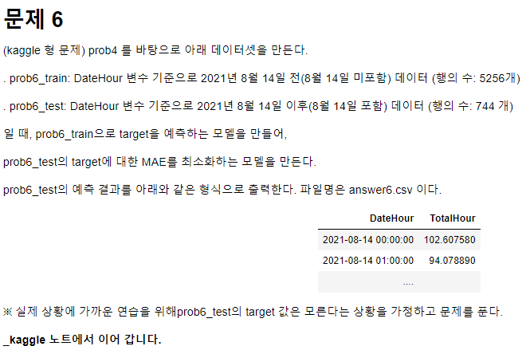

```python
Image('1-5.png')
```